# Advancing an interdisciplinary framework to study seed dispersal ecology | AoB PLANTS | Oxford Academic

## Gap 1: Understanding the movement ecology of seeds

This first knowledge gap focuses on improving our mechanistic understanding of the movement of individual seeds in order to generalize dispersal mechanisms and patterns across systems and to predict dispersal under novel conditions. Studies uncovering spatial patterns of seed dispersal have tended to focus on population-level patterns (e.g. Eulerian methods), but are becoming increasingly mechanistic by focusing on the movement of individual seeds (e.g. Langrarian approaches; [Turchin 1998](https://academic.oup.com/aobpla/article/12/2/plz048/5550899)). To describe population-level spatial patterns of seed dispersal, ecologists have estimated dispersal kernels (probability density function of dispersal distances; [Nathan *et al.* 2012](https://academic.oup.com/aobpla/article/12/2/plz048/5550899)) by combining seed traps with inverse modeling ([Nathan and Muller-Landau 2000](https://academic.oup.com/aobpla/article/12/2/plz048/5550899)) and incorporating genetic information from seeds and parents (e.g. [Hardesty 2007](https://academic.oup.com/aobpla/article/12/2/plz048/5550899); [Jones and Muller-Landau 2008](https://academic.oup.com/aobpla/article/12/2/plz048/5550899)). While these analyses increase our understanding of the variation in seed dispersal patterns, dispersal kernels tend to be phenomenological ([Nathan *et al.* 2012](https://academic.oup.com/aobpla/article/12/2/plz048/5550899); but see [Katul *et al.* 2005](https://academic.oup.com/aobpla/article/12/2/plz048/5550899); [Codling *et al.* 2008](https://academic.oup.com/aobpla/article/12/2/plz048/5550899) for examples of mechanistically derived dispersal kernels) and therefore have limited capability for forecasting changes in dispersal itself under novel conditions resulting from global change. In addition, these phenomenological models tend to describe the spatial patterns of seeds arising from the final outcome of dispersal and not the process of dispersal, while a mechanistic understanding can only be achieved by partitioning the contributions of different dispersal vectors (see [Rogers *et al.* 2019](https://academic.oup.com/aobpla/article/12/2/plz048/5550899) for solutions to this issue).

A more mechanistic understanding of the movement of individual seeds requires explicitly quantifying the action and movement of different seed dispersal vectors and their interactions with plants. A challenge will be measuring the extent of long-distance dispersal (LDD), rare events that are particularly difficult to study but likely critical to the establishment of new populations, colonization after disturbance and rapid plant migration in response to climate change ([Nathan 2006](https://academic.oup.com/aobpla/article/12/2/plz048/5550899)). Finally, we need to be able to scale up movements of individual seeds to effectively generalize and predict spatial patterns that emerge at the population level. Development of models informed by empirical data will help us incorporate the necessary level of complexity for dispersal vectors and their interactions with plants, measure the extent of LDD and scale from the movement of individual seeds to describe population-level spatial patterns.

### Action/movement of seed dispersal vectors

Across species, plants are dispersed by a range of dispersal vectors; even an individual seed may be dispersed by a suite of abiotic and biotic means. These vectors have different consequences for seed dispersal patterns and require a range of empirical and mathematical methods to uncover and describe associated processes ([Fig. 4](https://academic.oup.com/aobpla/article/12/2/plz048/5550899)). Investigating all the actions, movements and processes influencing the journey of a seed at the plant, population or species level is daunting but a mechanistic understanding is possible by integrating empirical and theoretical approaches. One approach is to describe functional groups to generalize across species as discussed by [Aslan *et al.* (2019)](https://academic.oup.com/aobpla/article/12/2/plz048/5550899). Another is to draw general lessons from analysis of total dispersal kernels for key species ([Rogers *et al.* 2019](https://academic.oup.com/aobpla/article/12/2/plz048/5550899)). Here, we highlight data-driven quantitative approaches that enable researchers to describe these complex processes and advance a mechanistic understanding of different vectors, focusing on wind, water and animals, including humans.

Figure 4.

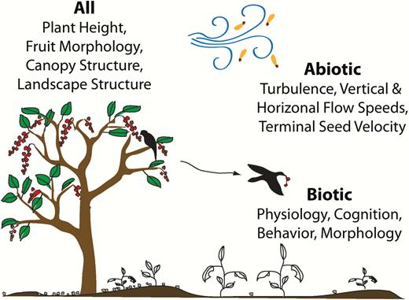

Examples of processes influencing abiotically and biotically dispersed seeds.

[figure not shown]

For abiotically dispersed plant species, we can gain an increased mechanistic understanding of dispersal processes from physics and hydrology. The physics of the transport of propagules—such as spores, pollen and seeds—due to the action of wind or water is a vast field in its own right (e.g. [Okubo and Levin 1989](https://academic.oup.com/aobpla/article/12/2/plz048/5550899); [Isard and Gage 2001](https://academic.oup.com/aobpla/article/12/2/plz048/5550899); [Katul *et al.* 2005](https://academic.oup.com/aobpla/article/12/2/plz048/5550899); [Nathan *et al.* 2011b](https://academic.oup.com/aobpla/article/12/2/plz048/5550899); [Aylor 2017](https://academic.oup.com/aobpla/article/12/2/plz048/5550899)). For wind dispersal, a typical seed dispersal event first involves release of a seed from the plant canopy. For plants in the herbaceous layer, seeds are generally dispersed above the canopy, and any seeds released under the canopy settle immediately due to very low wind speeds ([Soons *et al.* 2004](https://academic.oup.com/aobpla/article/12/2/plz048/5550899)). For trees and shrubs, the seed will experience dispersal within the canopy due to canopy-scale turbulence, sometimes followed by escape from the canopy and transport via the surface layer or even higher levels of the atmospheric boundary layer, before being deposited ([Augspurger 1986](https://academic.oup.com/aobpla/article/12/2/plz048/5550899)). Each of these steps involves turbulence and advective flows with different properties. Hence, one of the challenges is to connect dispersal processes that dominate at different scales ([Pauchard and Shea 2006](https://academic.oup.com/aobpla/article/12/2/plz048/5550899)). A variety of numerical simulation methods have been developed, including Lagrangian stochastic models ([Katul *et al.* 2005](https://academic.oup.com/aobpla/article/12/2/plz048/5550899); [Kuparinen 2006](https://academic.oup.com/aobpla/article/12/2/plz048/5550899); [Aylor 2017](https://academic.oup.com/aobpla/article/12/2/plz048/5550899)) and large eddy simulations ([Chamecki *et al.* 2009](https://academic.oup.com/aobpla/article/12/2/plz048/5550899); [Nathan *et al.* 2011b](https://academic.oup.com/aobpla/article/12/2/plz048/5550899)). These mechanistic models, varying in levels of complexity, have given us insights on the importance of seed abscission, canopy structure, plant height and land surface heterogeneity on LDD through effects on turbulence and wind speed, but additional advances in theory are required to generalize across systems ([Nathan *et al.* 2011b](https://academic.oup.com/aobpla/article/12/2/plz048/5550899)). For seed dispersal by water, obtaining a fine-scale resolution of flow requires numerically solving 3-D fluid-structure interaction equations, which is extremely expensive computationally. In other scenarios, 1-D analytical porous models may suffice to resolve flow through vegetative beds including sea grasses, reefs and macrophytes (e.g. [Brinkman 1949](https://academic.oup.com/aobpla/article/12/2/plz048/5550899); [Strickland *et al.* 2017](https://academic.oup.com/aobpla/article/12/2/plz048/5550899)). These modeling approaches for abiotically dispersed plant species can be further developed with advances in data collection. For example, remote sensing now enables 3-D characterizations of vegetation (e.g. [Lefsky *et al.* 2002](https://academic.oup.com/aobpla/article/12/2/plz048/5550899); [Eitel *et al.* 2016](https://academic.oup.com/aobpla/article/12/2/plz048/5550899)), and meteorological sensors (FLUXNET; [Baldocchi *et al.* 2001](https://academic.oup.com/aobpla/article/12/2/plz048/5550899)) allow monitoring speeds and turbulence of wind and water at high spatial and temporal resolutions.

The dispersal of a seed by an animal depends on the vector’s life-history strategy, local abundances and distributions of dispersers and fruiting trees, landscape structure, and individual characteristics of the animal and fruit themselves ([Nathan *et al.* 2008](https://academic.oup.com/aobpla/article/12/2/plz048/5550899); [Cortes and Uriarte 2012](https://academic.oup.com/aobpla/article/12/2/plz048/5550899); [Schupp *et al.* 2019](https://academic.oup.com/aobpla/article/12/2/plz048/5550899); [Snell *et al.* 2019](https://academic.oup.com/aobpla/article/12/2/plz048/5550899)). Spatially explicit individual-based models (IBMs) can integrate data on dispersal processes, such as gut retention time, animal movement and number of seeds dispersed, to determine the spatial locations of seeds and contribution to long-distance seed dispersal. For example, [Kleyheeg *et al.* (2017)](https://academic.oup.com/aobpla/article/12/2/plz048/5550899) predicted seed dispersal patterns by the mallard (*Anas platyrhynchos*), an important dispersal vector of wetland plants, by using a spatially explicit, mechanistic simulation model developed from high-resolution data on gut-passage times and landscape-scale movements of the mallard. [Pires *et al.* (2018)](https://academic.oup.com/aobpla/article/12/2/plz048/5550899) estimated that LDD reduced by at least two-thirds following extinctions of mammals in specific Pleistocene assemblages using a mechanistic simulation model incorporating seed ingestion, gut retention, animal movement and seed deposition. Animal movement relevant to seed dispersal can occur across multiple spatiotemporal scales; for example, an animal may forage at fine spatial and temporal scales but search for foraging sites at long distances. The movement path of an individual arises from an animal’s internal state, navigation capacity, motion capacity and the environment ([Nathan *et al.* 2008](https://academic.oup.com/aobpla/article/12/2/plz048/5550899)). Multiple behaviours of animal movement are quantified using observational data on the locations of individual animals collected at predetermined fixed time intervals, and some of the derived quantities used to describe movement are sensitive to the choice of sampling rate. These sampling rates should be guided by the research question and the movement process under investigation. [Fleming *et al.* (2014)](https://academic.oup.com/aobpla/article/12/2/plz048/5550899) recently developed an approach using a semi-variance function of a stochastic movement process that enables identification of multiple modes of animal movement that vary across spatiotemporal timescales (e.g. foraging, simple random search and home range) and provides a solution to the sampling rate problem. Using this approach, they were able to incorporate foraging behaviour into existing animal movement models. Finally, understanding the preference and avoidance of certain habitats within the landscape by animal seed dispersers will be necessary for determining subsequent growth and survival of plants after deposition. For example, [Kleyheeg *et al.* (2017)](https://academic.oup.com/aobpla/article/12/2/plz048/5550899) found that landscape configuration governs mallard movements, and transport of seeds to core areas may help maintain connectivity of wetland plant populations.

To better understand the mechanisms of seed dispersal in socioecological systems, we need to consider both accidental and deliberate seed dispersal by humans (e.g. [Wichmann *et al.* 2009](https://academic.oup.com/aobpla/article/12/2/plz048/5550899); [Taylor *et al.* 2012](https://academic.oup.com/aobpla/article/12/2/plz048/5550899)), which can occur over great distances that are potentially global in scale ([Bullock *et al.* 2018](https://academic.oup.com/aobpla/article/12/2/plz048/5550899)). Methods are being developed to quantify and model seed dispersal by humans. Relevant advances in invasion biology include genetic analysis to identify seed sources (e.g. [Eriksen *et al.* 2014](https://academic.oup.com/aobpla/article/12/2/plz048/5550899)), transportation/shipping route mapping (e.g. [Miller and Ruiz 2014](https://academic.oup.com/aobpla/article/12/2/plz048/5550899); [Chapman *et al.* 2017](https://academic.oup.com/aobpla/article/12/2/plz048/5550899)) and socioecological studies of human behaviours and movements (e.g. [Wilson *et al.* 2016](https://academic.oup.com/aobpla/article/12/2/plz048/5550899)). From the results of these studies, some of these interactions may be generalizable and predictable (e.g. based on plant traits; [Bullock *et al.* 2018](https://academic.oup.com/aobpla/article/12/2/plz048/5550899)). For example, vehicles were observed to disperse seeds in a directional manner in Berlin, in which seed traps near outbound lanes tended to have native seeds and exotic non-crop seeds, while inbound lanes tended to have exotic crops ([von der Lippe and Kowarik 2008](https://academic.oup.com/aobpla/article/12/2/plz048/5550899)).

Recent empirical advances can aid a mechanistic understanding of seed dispersal and the development of mechanistic models described above (e.g. [Nathan *et al.* 2011b](https://academic.oup.com/aobpla/article/12/2/plz048/5550899); [Cortes and Uriarte 2012](https://academic.oup.com/aobpla/article/12/2/plz048/5550899)). These advances include detailed data on seed movement (e.g. stable isotopes: [Carlo *et al.* 2009](https://academic.oup.com/aobpla/article/12/2/plz048/5550899); radio transmitters: [Hirsch *et al.* 2012](https://academic.oup.com/aobpla/article/12/2/plz048/5550899); DNA barcoding: [González-Varo *et al.* 2014](https://academic.oup.com/aobpla/article/12/2/plz048/5550899)), animal movement (e.g. Movebank: [Kranstauber *et al.* 2011](https://academic.oup.com/aobpla/article/12/2/plz048/5550899); integrating GPS tracking with remote sensing: [Kays *et al.* 2015](https://academic.oup.com/aobpla/article/12/2/plz048/5550899); animal-borne sensors: [Wilmers *et al.* 2015](https://academic.oup.com/aobpla/article/12/2/plz048/5550899)) and the abiotic environment ([Baldocchi *et al.* 2001](https://academic.oup.com/aobpla/article/12/2/plz048/5550899); [Davies and Asner 2014](https://academic.oup.com/aobpla/article/12/2/plz048/5550899)). For example, using telemetric thread tags ([Hirsch *et al.* 2012](https://academic.oup.com/aobpla/article/12/2/plz048/5550899)), [Jansen *et al.* (2012)](https://academic.oup.com/aobpla/article/12/2/plz048/5550899) found that secondary dispersers have a greater role in LDD than previously thought. In addition, future research can link trait data (e.g. TRY: [Kattge *et al.* 2011](https://academic.oup.com/aobpla/article/12/2/plz048/5550899); D<sup>3</sup>: [Hintze *et al.* 2013](https://academic.oup.com/aobpla/article/12/2/plz048/5550899); KEW: [Royal Botanic Gardens Kew 2016](https://academic.oup.com/aobpla/article/12/2/plz048/5550899)) to dispersal processes to help reduce complexity of interactions and models ([Aslan *et al.* 2019](https://academic.oup.com/aobpla/article/12/2/plz048/5550899)). The quantity of data relevant for dispersal is increasing into the realm of big data ([Allan *et al.* 2018](https://academic.oup.com/aobpla/article/12/2/plz048/5550899)), and rapid access is eased through curated repositories. These repositories can be used to improve our ability to incorporate intraspecific variation in seed dispersal ([Schupp *et al.* 2019](https://academic.oup.com/aobpla/article/12/2/plz048/5550899)), which can have important consequences for plant populations, communities and evolution ([Snell *et al.* 2019](https://academic.oup.com/aobpla/article/12/2/plz048/5550899); [Schreiber and Beckman 2020](https://academic.oup.com/aobpla/article/12/2/plz048/5550899)). While current advances allow us to study dispersal vector characteristics at very fine spatial and temporal resolution, the question remains whether this also captures variation among and within populations and species.

### Long-distance dispersal

Long-distance dispersal—often a rare event—is critical to the spread of populations ([Ferrandino 1993](https://academic.oup.com/aobpla/article/12/2/plz048/5550899); [Kot *et al.* 1996](https://academic.oup.com/aobpla/article/12/2/plz048/5550899); [Hastings *et al.* 2005](https://academic.oup.com/aobpla/article/12/2/plz048/5550899)). Advances have been made in operationalizing the concept of LDD, but challenges remain concerning how to measure these rare events. [Jordano (2017)](https://academic.oup.com/aobpla/article/12/2/plz048/5550899) recently introduced operative definitions of LDD using a demographic perspective in which propagules can contribute to LDD by expanding a species’ range when they colonize new areas outside of the source population or disperse away from close relatives outside of the genetic neighbourhood in which parents mate. He identified three types of LDD: (i) LDD within the genetic neighbourhood, (ii) short-distance dispersal outside of the genetic neighbourhood and (iii) strict-sense LDD (i.e. LDD outside the genetic neighbourhood). The question remains: once operationalized, how do we measure such rare events? This remains a major challenge in empirical ecology, but perspectives from population genetics, statistics, and physics are improving our ability to empirically measure the importance of LDD in gene flow and species distributions.

Genetic analysis of populations can link individuals to their source populations and has been a useful tool for understanding the importance of rare, long-distance events in colonizing new areas. Using genetic information from 25 species, Alsos and colleagues found that multiple dispersal events from several source regions contributed to post-glacial colonization of five islands in the Arctic; source regions were 280 to >3000 km away and were frequently not the closest ones—suggesting a greater role for deterministic rather than stochastic factors resulting in LDD ([Alsos *et al.* 2007](https://academic.oup.com/aobpla/article/12/2/plz048/5550899), [2015](https://academic.oup.com/aobpla/article/12/2/plz048/5550899)). Landscape genetics reveal that multiple LDD events were also responsible for mountain hemlock colonization on Alaska’s Kenai Peninsula (USA) following Pleistocene glaciation ([Johnson *et al.* 2017](https://academic.oup.com/aobpla/article/12/2/plz048/5550899)). Using molecular techniques, observations of fruit consumption, and data from seed traps and faeces, [Jordano *et al.* (2007)](https://academic.oup.com/aobpla/article/12/2/plz048/5550899) were able to quantify the contribution of different dispersal vectors to LDD for the mahaleb cherry (*Prunus mahaleb*) and found that LDD of this plant species is driven by a small subset of large frugivores. Citizen science projects can also shed light on the extent and magnitude of LDD events. For example, in Sweden, [Auffret and Cousins (2013)](https://academic.oup.com/aobpla/article/12/2/plz048/5550899) found that humans dispersed meadow species, especially those with hooked or appendaged seeds and persistent seed banks, from 1.3 to 110 km.

Extreme value theory, introduced by [Gumbel (1958)](https://academic.oup.com/aobpla/article/12/2/plz048/5550899), can be applied to dispersal distances obtained from molecular tools, tracking dispersal vector movement and censored data (e.g. the maximum observed distance moved from a fruiting tree) to estimate the frequency and extent of rare dispersal events. This statistical technique has been widely used in other disciplines such as climatology, hydrology, engineering, insurance, finance and, more recently, ecology to estimate the frequency and extent of rare events, for example, the return interval of large floods (e.g. [Gaines and Denny 1993](https://academic.oup.com/aobpla/article/12/2/plz048/5550899); [Gutschick and BassiriRad 2003](https://academic.oup.com/aobpla/article/12/2/plz048/5550899)). Extreme value statistics have been applied to the study of plant dispersal only very recently, likely due to limited data in the past ([García *et al.* 2017](https://academic.oup.com/aobpla/article/12/2/plz048/5550899)). Using data on seed dispersal distances obtained from genetic analyses of the vertebrate-dispersed mahaleb cherry, [García *et al.* (2017)](https://academic.oup.com/aobpla/article/12/2/plz048/5550899) found that seeds could be dispersed outside of the focal population with low, but non-zero probability (Pr(*X* ≥ 1 km) = 0.10, Pr(*X* ≥ 5 km) = 4 × 10<sup>−4</sup> and Pr(*X* ≥ 10 km) = 7 × 10<sup>−5</sup>). Extreme value statistics can give insight into invasions, the loss of dispersal services or the likelihood of populations tracking suitable habitat ([García *et al.* 2017](https://academic.oup.com/aobpla/article/12/2/plz048/5550899)), and may therefore be useful for generalizing across systems. However, these methods are phenomenological models fit to existing data and assume stationarity, while extreme value statistics are likely to shift under global change.

Physics can contribute insights on measuring rare events mechanistically, which can help in predicting LDD under global change. In nature, there are two types of rare events: (i) discrete and uncorrelated, such as an unusually long pause between two consecutive events in a Poisson process, and (ii) a sequence of cumulative rare events. Long-distance dispersal by animals is most likely of the first type. Long-distance dispersal by wind is most likely of the second type, as an unlikely sequence of turbulent events sustain the seed in the air for an unlikely long period of time (all the while being pushed by wind in the direction parallel to the ground). Physicists have developed a powerful approach for understanding the statistics and dynamics of a sequence of cumulative rare events. A rare chain of events connects the initial and final state. In the case of a LDD event, the initial and final states would be the source and destination locations of a propagule. An event would be considered rare, if the dispersal event was much longer than a typical dispersal event (quantified, for instance, by the standard deviation of dispersal distances). The key insight behind this approach is that a very unlikely chain of events (e.g. a dispersal event that is much longer than a typical dispersal event) unfolds along an essentially deterministic realization—the least unlikely out of all unlikely realizations connecting these initial and final states. The more unlikely the chain of events, the more it will be dominated by this least unlikely realization (or chain of events). Deviations around this ‘optimal path’ quickly decrease in probability, even though the probability of this least unlikely path is also small (given some fixed waiting time). The Wentzel, Kramers, Brillouin (WKB) theory—originally developed for calculating the rates of (rare) tunnelling events in Quantum Mechanics—has found applications in fields as diverse as population biology and epidemiology in recent years ([Ovaskainen and Meerson 2010](https://academic.oup.com/aobpla/article/12/2/plz048/5550899)). This WKB theory is the method by which an optimal path (or trajectory) can be found, and the probability of a rare event can be evaluated. Given the properties of noise (e.g. its correlation function), the method gives a certain cost function that measures the relative probability of any one path. Minimizing this cost function over the functional space of paths gives the optimal path, and the cost function along the optimal path gives the dominant contribution to the probability of a rare event. Attempts are currently under way to adapt this theory to hydrodynamics ([Laurie and Bouchet 2015](https://academic.oup.com/aobpla/article/12/2/plz048/5550899); [Bouchet *et al.* 2018](https://academic.oup.com/aobpla/article/12/2/plz048/5550899)), overcoming challenges imposed by the high dimensionality of dynamics involved. [Ovaskainen and Meerson (2010)](https://academic.oup.com/aobpla/article/12/2/plz048/5550899) provide both an accessible exposition of this technique and its biological applications, and a clear explanation of challenges of applying these ideas in complex situations.

### Scaling from individual seed movements to population-level patterns

Both generalizing and predicting population-level patterns of seed dispersal from the movements of individual seeds require relevant advances in data, mathematics and computation. First, it requires a detailed understanding of the mechanisms of the focal system as introduced above and the natural histories of the relevant players. Second, it requires mathematical and computational advances that efficiently scale from interactions occurring over short time scales (on the order of minutes) and spatial scales (on the order of mm–cm) to patterns emerging over months to years across landscapes and regions. Modeling population-level patterns of the movement of individual seeds in response to the action, behaviour and movement of dispersal vectors can be computationally expensive and require extensive data for calibration. There are only a few plant species for which complex, mechanistic models have been developed and for which enough data exist to parameterize these models to predict population-level spatial patterns of seed dispersal from individual seed movements ([Nathan *et al.* 2011b](https://academic.oup.com/aobpla/article/12/2/plz048/5550899); [Cortes and Uriarte 2012](https://academic.oup.com/aobpla/article/12/2/plz048/5550899)). These models are better-developed for ballistic- and wind-dispersed plants than animal-dispersed plants ([Nathan *et al.* 2011b](https://academic.oup.com/aobpla/article/12/2/plz048/5550899); [Cortes and Uriarte 2012](https://academic.oup.com/aobpla/article/12/2/plz048/5550899)), in large part because of the complexity of animal behaviour and movement ([Zwolak 2018](https://academic.oup.com/aobpla/article/12/2/plz048/5550899)). However, the field of animal movement ecology has advanced tremendously over the last decades with tracking and analytical methods constantly improving ([Börger 2016](https://academic.oup.com/aobpla/article/12/2/plz048/5550899)). Collaborating more closely with animal movement researchers opens up new opportunities for developing improved models of animal-dispersed plants.

To scale from individual movements to population-level patterns, we can approximate complex mechanistic models with models that make simplifying assumptions. One multi-scale mathematical approach is to begin with random walks of individuals and use various approximations to arrive at diffusion or transport equations that describe the collective movement of individuals ([Turchin 1998](https://academic.oup.com/aobpla/article/12/2/plz048/5550899); [Codling *et al.* 2008](https://academic.oup.com/aobpla/article/12/2/plz048/5550899)). Coupled with functions of seed retention time ([Bullock *et al.* 2011](https://academic.oup.com/aobpla/article/12/2/plz048/5550899)), these approximations can describe seed dispersal by animals and give important insight into how variability in retention times (in animal guts or externally) influences LDD ([Guttal *et al.* 2011](https://academic.oup.com/aobpla/article/12/2/plz048/5550899)). A fluid dynamics approach used by physicists, hydrologists and atmospheric modellers can help overcome challenges in scaling from the local interactions of a seed with the physical dynamics of wind and water to large-scale dispersal patterns. Under certain assumptions, the effect of wind on the dispersal kernel and LDD can be approximated using analytical mathematical results, such as the Wald analytical LDD model (e.g. [Katul *et al.* 2005](https://academic.oup.com/aobpla/article/12/2/plz048/5550899)). The empirical, analytical and numerical methods for the treatment of abiotic dispersal in heterogeneous landscapes require further development in future research ([Brinkman 1949](https://academic.oup.com/aobpla/article/12/2/plz048/5550899); [Bohrer *et al.* 2008](https://academic.oup.com/aobpla/article/12/2/plz048/5550899); [Nathan *et al.* 2011b](https://academic.oup.com/aobpla/article/12/2/plz048/5550899); [Katul and Poggi 2012](https://academic.oup.com/aobpla/article/12/2/plz048/5550899); [Trakhtenbrot *et al.* 2014](https://academic.oup.com/aobpla/article/12/2/plz048/5550899)). Advances have been made on this front by [Powell and Zimmermann (2004)](https://academic.oup.com/aobpla/article/12/2/plz048/5550899), who developed an analytical solution to approximate the migration of plants dispersed by animals based on the theory of homogenization, which could be extended to abiotically dispersed plants. Through this technique, [Powell and Zimmermann (2004)](https://academic.oup.com/aobpla/article/12/2/plz048/5550899) incorporated caching activity by harvester ants for wild ginger (*Asarum canadense*), by Blue Jays (*Cyanocitta cristata*) for oaks (*Quercus*) and by Clark’s nutcrackers (*Nucifraga columbiana*) for whitebark pine (*Pinus albicaulis*), and were able to predict migration rates of trees that matched the paleo-record, except in the case of the Holocene migration of wild ginger.

Future research can advance mechanistic dispersal kernels and predictive seed dispersal ecology. First, dispersal kernels can better incorporate interactions between dispersal vectors and individual seeds, which tend to occur across multiple spatial and temporal scales. For example, different dispersal mechanisms can be incorporated mathematically into the dispersal kernel, which gives the long-term limit after all seeds land, to evaluate the effects of different vectors quantitatively using methods from applied mathematics ([Rogers *et al.* 2019](https://academic.oup.com/aobpla/article/12/2/plz048/5550899)). Second, dispersal kernels should account for non-stationarity in driving factors and depend on the environment. That way, kernels can change with time, space and shifts in the environment, important for predicting dispersal in novel landscapes. Standardized data initiatives provide a valuable means for evaluating the magnitude and causes of non-stationarity across space and time. Third, integrating multiple dispersal vectors, non-stationary dispersal kernels, and improved and standardized dispersal vector monitoring and data collection with process-based models will allow predicting the spatiotemporal distribution of seeds of entire populations across the landscape.

## Gap 2: Understanding the demographic consequences of seed dispersal

So far, we have discussed how to understand seed dispersal as a process. To understand the importance of seed dispersal for the dynamics of a population over multiple generations, we need to understand how this process interacts with stages across a plant’s entire life cycle, from seed production through juvenile and adult survival and growth. Prediction of the demographic consequences of seed dispersal remains a large challenge due to the context dependence of seed dispersal ([Schupp *et al.* 2010](https://academic.oup.com/aobpla/article/12/2/plz048/5550899)), heterogeneity of the environment ([Nathan *et al.* 2011a](https://academic.oup.com/aobpla/article/12/2/plz048/5550899)), the long lifespans of many adult plants and interdependent processes occurring over multiple spatial and temporal scales ([Mokany *et al.* 2014](https://academic.oup.com/aobpla/article/12/2/plz048/5550899)). A promising path forward is integrating the Seed Dispersal Effectiveness Framework ([Schupp 1993](https://academic.oup.com/aobpla/article/12/2/plz048/5550899); [Schupp *et al.* 2010](https://academic.oup.com/aobpla/article/12/2/plz048/5550899)) with advances in mathematical and computational methods (e.g. [Godinez-Alvarez and Jordano 2007](https://academic.oup.com/aobpla/article/12/2/plz048/5550899); [Cortes and Uriarte 2012](https://academic.oup.com/aobpla/article/12/2/plz048/5550899)). The Seed Dispersal Effectiveness Framework—an important progression in embracing the context dependence of seed dispersal and moving towards an ability to generalize across systems—provides a roadmap for evaluating the contribution of each dispersal vector to the production of a new adult by evaluating the *quantity* of seeds dispersed and *quality* of seed dispersal in different contexts ([Schupp 1993](https://academic.oup.com/aobpla/article/12/2/plz048/5550899); [Schupp *et al.* 2010](https://academic.oup.com/aobpla/article/12/2/plz048/5550899)). This information can be incorporated into process-based dynamic models of populations to examine the influence of dispersal compared to other life-history stages on the growth and spread of populations over multiple generations as discussed below.

### Local population dynamics

To evaluate the role of seed dispersal in population dynamics, we need to explicitly integrate over critical determinants of seed dispersal effectiveness ([Schupp *et al.* 2010](https://academic.oup.com/aobpla/article/12/2/plz048/5550899)), including pre-dispersal, dispersal and post-dispersal processes operating across different life stages. Hitherto, the Seed Dispersal Effectiveness Framework has mostly been applied to single species (but see [Donoso *et al.* 2016](https://academic.oup.com/aobpla/article/12/2/plz048/5550899); [Fricke *et al.* 2018](https://academic.oup.com/aobpla/article/12/2/plz048/5550899)), but [Aslan *et al.* (2019)](https://academic.oup.com/aobpla/article/12/2/plz048/5550899) outline an approach to generalize across functional groups. Such attempts at generalizing seed dispersal effectiveness across species and systems are necessary because empirical data for operationalizing the Seed Dispersal Effectiveness Framework are still scarce (but see [Simmons *et al.* 2018](https://academic.oup.com/aobpla/article/12/2/plz048/5550899)). For example, data on dispersal and its delayed consequences for plant survival and growth are limited in temporal scale, following seeds for only a few years ([Clark *et al.* 1999a](https://academic.oup.com/aobpla/article/12/2/plz048/5550899); [Howe and Miriti 2004](https://academic.oup.com/aobpla/article/12/2/plz048/5550899)), and are highly species-specific, with data amount and quality varying widely among plant species and interacting species that influence plant dispersal, growth and survival ([Agrawal *et al.* 2007](https://academic.oup.com/aobpla/article/12/2/plz048/5550899)). Additionally, for long-lived plants such as trees, we are limited to collecting data on the early stages of recruitment. As a result, it is unclear how variation in dispersal and heterogeneity in the seedscape across space and time will influence later stages of recruitment. Population models constitute an alternative approach, and parameterizing population models with observational and experimental data on the effectiveness of different dispersal vectors and their deposition in varying seedscapes helps elucidate the role of dispersal in the demographic process (e.g. [Brodie *et al.* 2009b](https://academic.oup.com/aobpla/article/12/2/plz048/5550899)). Local population dynamics can be modelled to assume a range of biological complexity (reviewed in [Jongejans *et al.* 2008](https://academic.oup.com/aobpla/article/12/2/plz048/5550899)). Such models include unstructured population models (e.g. exponential growth), structured population models that include stages or ages (e.g. matrix population models [MPMs]; [Caswell 2001](https://academic.oup.com/aobpla/article/12/2/plz048/5550899)), spatially explicit IBMs (e.g. [Adler and Muller-Landau 2005](https://academic.oup.com/aobpla/article/12/2/plz048/5550899); [Beckman *et al.* 2012](https://academic.oup.com/aobpla/article/12/2/plz048/5550899)) and dynamic vegetation models (DVMs; [Snell *et al.* 2014](https://academic.oup.com/aobpla/article/12/2/plz048/5550899)).

An extremely powerful set of analytical tools have been developed for both MPMs and integral projection models (IPMs) to predict population growth rate, stable stage distribution and sensitivity to small perturbations in the model parameters ([Caswell 2001](https://academic.oup.com/aobpla/article/12/2/plz048/5550899); [Ellner and Rees 2006](https://academic.oup.com/aobpla/article/12/2/plz048/5550899)). These analytical models rely on the law of large numbers, and thus model mean populations that encounter each other in proportion to their average abundance (i.e. a mean-field assumption), generally assume homogeneous environments, and provide asymptotic results. Such structured population models are useful to examine different hypotheses of how present conditions influence populations by examining population projections ([Caswell 2001](https://academic.oup.com/aobpla/article/12/2/plz048/5550899)). We can use these models to analyse the population growth rate and its sensitivity under different dispersal scenarios (e.g. no dispersal, one dispersal vector, a community of dispersal vectors), and this has improved our understanding of whether and under what conditions dispersal is important for a particular species and our ability to predict the consequences of shifting the community of dispersal vectors. For example, [Godinez-Alvarez and Jordano (2007)](https://academic.oup.com/aobpla/article/12/2/plz048/5550899) proposed integrating the Seed Dispersal Effectiveness Framework with MPMs to evaluate the influence of dispersal vectors on the dynamics of plant populations. By building the projection matrix based on the quantity and quality of dispersal by one bat and three bird seed dispersers, [Godinez-Alvarez and Jordano (2007)](https://academic.oup.com/aobpla/article/12/2/plz048/5550899) found that dispersal vector identity influenced population growth rates of the cactus *Neobuxbaumia tetetzo*. In MPMs, plants are categorized in discrete stages by size or life-history stage (e.g. seed, seedling, juvenile, adult), which is more appropriate for plants as they can remain in the same stage for multiple years and/or have unknown or difficult-to-measure ages. Integral projection models can accommodate both discrete and continuous descriptions of fecundity, survival and growth based on size and age ([Easterling *et al.* 2000](https://academic.oup.com/aobpla/article/12/2/plz048/5550899)), which is especially important for long-lived species as individual variation within stages can influence population dynamics ([Zuidema *et al.* 2010](https://academic.oup.com/aobpla/article/12/2/plz048/5550899)). The dynamics of transients, important in the conservation and management of populations, can also be analysed ([Caswell 2006](https://academic.oup.com/aobpla/article/12/2/plz048/5550899)). For example, [Elwood *et al.* (2018)](https://academic.oup.com/aobpla/article/12/2/plz048/5550899) showed that scatter-hoarders can have significant effects on both short- and long-term population dynamics of American Chestnut (*Castanea dentata*). An important advance in analysing dynamics of structured population models is the development of tools to examine consequences of random variation in vital rates (i.e. stochastic demography; [Boyce *et al.* 2006](https://academic.oup.com/aobpla/article/12/2/plz048/5550899)). This stochastic variation affects estimates of population growth, persistence and resilience compared to deterministic versions of structured population models ([Boyce *et al.* 2006](https://academic.oup.com/aobpla/article/12/2/plz048/5550899)). As anthropogenic pressures can increase or decrease environmental variability, the implications of this variation for demography should be carefully considered (e.g. [Snell *et al.* 2019](https://academic.oup.com/aobpla/article/12/2/plz048/5550899)). In addition, future research can explicitly include post-dispersal mechanisms, such as competition, mortality due to natural enemies and microsite suitability for growth ([Howe and Miriti 2004](https://academic.oup.com/aobpla/article/12/2/plz048/5550899)) into these suite of population models to increase their capability of predicting dynamics in response to novel conditions.

To explicitly incorporate post-dispersal processes, researchers could use a systems approach to examine the influence of dispersal by animals on local plant dynamics. [Cortes and Uriarte (2012)](https://academic.oup.com/aobpla/article/12/2/plz048/5550899) proposed integrating the Seed Dispersal Effectiveness Framework with the movement ecology paradigm developed by [Nathan and colleagues (2008)](https://academic.oup.com/aobpla/article/12/2/plz048/5550899) that combines internal states, motion and navigation capacities of individuals with external factors to study movement. This could be done with IBMs ([Grimm and Railsback 2005](https://academic.oup.com/aobpla/article/12/2/plz048/5550899)) or DVMs ([Snell *et al.* 2014](https://academic.oup.com/aobpla/article/12/2/plz048/5550899)). For example, [Loayza and Knight (2010)](https://academic.oup.com/aobpla/article/12/2/plz048/5550899) used an IBM parameterized by field studies on seed dispersal movement and the quantitative and qualitative components of seed dispersal effectiveness for two bird dispersers of the tree *Guettarda viburnoides* in a forest-savanna mosaic in Bolivia. Their model predicted that dispersal by Purplish Jays (*Cyanocorax cyanomelas*; pulp consumers which frequently dropped seeds) increased population growth due to a positive impact of seed handling and an increased likelihood of reaching suitable habitat (woody patches), whereas dispersal by Chestnut-eared Aracaris (*Pteroglossus castanotis*; ‘legitimate’ seed dispersers that swallow the fruit whole and pass the endocarp intact) decreased population growth, due to dispersal to unsuitable habitats (forest islands). Dynamic vegetation models include demographic, ecological and physiological processes as well as biotic interactions (i.e. competition) and range from models that simulate forest dynamics through growth and mortality of individual trees to models that simulate biogeochemical cycles and vegetation distributions through plant functional types ([Snell *et al.* 2014](https://academic.oup.com/aobpla/article/12/2/plz048/5550899)). However, only a few DVMs currently include seed dispersal (e.g. [Sato *et al.* 2007](https://academic.oup.com/aobpla/article/12/2/plz048/5550899); [Snell 2014](https://academic.oup.com/aobpla/article/12/2/plz048/5550899); [Snell and Cowling 2015](https://academic.oup.com/aobpla/article/12/2/plz048/5550899); [Lehsten *et al.* 2019](https://academic.oup.com/aobpla/article/12/2/plz048/5550899)), and none yet includes the level of detail outlined here. Dynamic vegetation models with more realistic seed dispersal processes can capture interactions in novel non-analogue environments, useful for predicting population dynamics when interspecific interactions and demographic processes shift.

Data requirements for population models can come from long-term observational studies, manipulative or accidental experiments (e.g. systems that have lost dispersers as a result of global change; [HilleRisLambers *et al.* 2013](https://academic.oup.com/aobpla/article/12/2/plz048/5550899)), or combinations thereof. Data on the dispersal process as discussed above, including the action/activity, occurrence, abundance and movement patterns of dispersal vectors, inform potential deposition sites of different dispersal vectors. Long-term data from censusing give information on survival, growth and recruitment through time and space (i.e. the quality of seed dispersal), necessary for long-lived species. Field and greenhouse experiments can provide detailed information on the suitability of deposition sites for plant recruitment. Seed addition experiments in different habitats can be used to quantify how the action/movement of different seed dispersal vectors influence recruitment in different microsite conditions ([Turnbull *et al.* 2000](https://academic.oup.com/aobpla/article/12/2/plz048/5550899); [Clark *et al.* 2007](https://academic.oup.com/aobpla/article/12/2/plz048/5550899)). To evaluate the influence of interspecific interactions within deposition sites, controlled greenhouse and field studies can exclude mycorrhizal and nurse–plant associations to measure the effect of these changes on plant growth and nutrient exchange ([van der Heijden 2010](https://academic.oup.com/aobpla/article/12/2/plz048/5550899)) or impose or simulate herbivory, seed predation, pathogen attack or parasitism to measure growth rates and other fitness correlates in the presence of natural enemies (e.g. [Agrawal 1999](https://academic.oup.com/aobpla/article/12/2/plz048/5550899)). Accidental experiments enable researchers to functionally manipulate dispersal or realistically simulate its absence and evaluate the impact across all life-history stages, not just those that are most tractable for experiments (e.g. seeds, small seedlings). For example, [Brodie *et al.* (2009a)](https://academic.oup.com/aobpla/article/12/2/plz048/5550899) predicted a decline in population growth rate of the canopy tree *Choerospondias axillairs* in over-hunted forests using a combination of accidental experiments, manipulative seed germination experiments, and population matrix models. How population growth rates differ depending on the quality of seed dispersal across different life-history stages and habitats can be investigated within population models using life table response experiment (LTRE) analyses ([Caswell 2001](https://academic.oup.com/aobpla/article/12/2/plz048/5550899)). A LTRE (term introduced by [Caswell 1989](https://academic.oup.com/aobpla/article/12/2/plz048/5550899)) compares vital rates under different experimental or observational conditions. A LTRE analysis examines differences in a demographic summary statistic derived from these vitals rates, such as population growth rate, across the study conditions. This is done by decomposing differences in the demographic summary statistic into contributions from the differences in vital rates across study conditions ([Caswell 1989](https://academic.oup.com/aobpla/article/12/2/plz048/5550899), [2001](https://academic.oup.com/aobpla/article/12/2/plz048/5550899)). For example, [Loayza and Knight (2010)](https://academic.oup.com/aobpla/article/12/2/plz048/5550899) used a LTRE analysis to compare population growth rates of the tree *G. viburnoides* between two habitats in which seeds are deposited by different bird seed dispersers. They decomposed the difference in predicted population growth due to contributions from the differences in seedling growth, small tree growth and adult tree fecundity ([Loayza and Knight 2010](https://academic.oup.com/aobpla/article/12/2/plz048/5550899)).

### Population spread

Dispersal and population spread are at the centre of a fundamental question in global change biology and invasion ecology ([Clark *et al.* 1998](https://academic.oup.com/aobpla/article/12/2/plz048/5550899); [Pauchard and Shea 2006](https://academic.oup.com/aobpla/article/12/2/plz048/5550899); [Jongejans *et al.* 2008](https://academic.oup.com/aobpla/article/12/2/plz048/5550899), [2011](https://academic.oup.com/aobpla/article/12/2/plz048/5550899); [Lockwood *et al.* 2013](https://academic.oup.com/aobpla/article/12/2/plz048/5550899)): if habitats change due to habitat destruction or climate change, will seed dispersal and population growth allow the plant population to track its suitable habitat? Or if a plant species’ seeds are transported into a novel habitat, will seed dispersal and population growth allow the species to naturalize or even become invasive? Information on dispersal processes and demographic transitions from the Seed Dispersal Effectiveness Framework can aid the development of models to predict the spread of populations invading new areas and evaluate the relative importance of seed dispersal. Analytical approaches used to model population spread include *reaction-diffusion models* that combine continuous time population models with diffusion (i.e. population-level approximation of random walks as discussed in *Scaling from individual seed movements to population-level patterns*), which are widely and successfully used in spatial ecology ([Okubo and Levin 2002](https://academic.oup.com/aobpla/article/12/2/plz048/5550899); [Cantrell and Cosner 2004](https://academic.oup.com/aobpla/article/12/2/plz048/5550899)). Their discrete time analogues, *integrodifference equations (IDEs)*, offer several appealing features for modeling plant populations. Integrodifference equations can incorporate discrete stage structure ([Neubert and Caswell 2000](https://academic.oup.com/aobpla/article/12/2/plz048/5550899)) and more closely represent seasonality in natural systems. They also offer greater flexibility in describing dispersal events via redistribution kernels (or probability density functions for seed shadows) ([Kot and Schaefer 1986](https://academic.oup.com/aobpla/article/12/2/plz048/5550899)). As discussed in the previous section, systems approaches can also be used to model population spread rates, which assume discrete interacting individuals. [Santini *et al.* (2016)](https://academic.oup.com/aobpla/article/12/2/plz048/5550899) found that IBMs predicted slower spread rates of mammals compared to an IDE, most likely due to the inherent stochasticity in IBMs. A functional perspective of seed dispersal effectiveness ([Aslan *et al.* 2019](https://academic.oup.com/aobpla/article/12/2/plz048/5550899)) could help the incorporation of dispersal into DVMs to simulate range shifts of plants ([Snell *et al.* 2014](https://academic.oup.com/aobpla/article/12/2/plz048/5550899)). For an overview of the types of models that integrate dispersal and demography, see [Jongejans *et al.* (2008)](https://academic.oup.com/aobpla/article/12/2/plz048/5550899).

Integrodifference equations (IDEs) have been used to examine the spread of invading organisms ([Kot *et al.* 1996](https://academic.oup.com/aobpla/article/12/2/plz048/5550899); [Hastings *et al.* 2005](https://academic.oup.com/aobpla/article/12/2/plz048/5550899); [Skarpaas and Shea 2007](https://academic.oup.com/aobpla/article/12/2/plz048/5550899)) and the influence of climate change on shifts in species ranges ([Zhou and Kot 2011](https://academic.oup.com/aobpla/article/12/2/plz048/5550899); [Harsch *et al.* 2014](https://academic.oup.com/aobpla/article/12/2/plz048/5550899)). Exponentially bounded kernels result in constant speed of population spread/invasion in integrodifference equations. However, fat-tailed kernels, such as the bivariate version of Student’s *t*-distribution that fits many dispersal vector–plant combinations ([Clark *et al.* 1999b](https://academic.oup.com/aobpla/article/12/2/plz048/5550899)), may lead to accelerating invasion speeds ([Kot *et al.* 1996](https://academic.oup.com/aobpla/article/12/2/plz048/5550899)). [Clark *et al.* (2001)](https://academic.oup.com/aobpla/article/12/2/plz048/5550899) developed an alternative approach to estimate finite spread rates using the expected velocity for the location of the furthest-forward individual. Using this method, they found slower spread rates than predicted by analytical models, and these slower rates were in line with paleorecords ([Clark *et al.* 2001](https://academic.oup.com/aobpla/article/12/2/plz048/5550899)). Mechanistic models for wind-dispersed species that incorporate dispersal and demography have been used to determine causes of variation and predict spread rates in response to climate-mediated changes in dispersal ([Nathan *et al.* 2011a](https://academic.oup.com/aobpla/article/12/2/plz048/5550899); [Bullock *et al.* 2012](https://academic.oup.com/aobpla/article/12/2/plz048/5550899); [Teller *et al.* 2016](https://academic.oup.com/aobpla/article/12/2/plz048/5550899)). Life table response experiment analyses (introduced in the previous section) of IDEs can determine the contributions of differences in demography and dispersal to differences in spread rates across populations as was done for both inter- and intraspecific bird populations by [Caswell *et al.* (2003)](https://academic.oup.com/aobpla/article/12/2/plz048/5550899) and different management scenarios of the annual herb *Rhinanthus minor* ([Bullock *et al.* 2008](https://academic.oup.com/aobpla/article/12/2/plz048/5550899)). By integrating seed dispersal effectiveness with LTRE analysis, researchers can examine how different dispersers influence population spread rates through their effects on demography and dispersal or how changes in vital rates and seed dispersal due to global change could influence population spread rates. Recent advances provide new opportunities to understand the influence of dispersal processes on population spread. Mathematicians have developed promising approaches to incorporate individual variation (spatial IPMs; [Jongejans *et al.* 2011](https://academic.oup.com/aobpla/article/12/2/plz048/5550899)), fragmented landscapes (i.e. reaction-diffusion models: [Maciel and Lutscher 2013](https://academic.oup.com/aobpla/article/12/2/plz048/5550899); integrodifference equations: [Gilbert *et al.* 2014](https://academic.oup.com/aobpla/article/12/2/plz048/5550899)), stochasticity ([Caswell *et al.* 2011](https://academic.oup.com/aobpla/article/12/2/plz048/5550899)) and temporally variable environments ([Caswell *et al.* 2011](https://academic.oup.com/aobpla/article/12/2/plz048/5550899); [Schreiber and Ryan 2011](https://academic.oup.com/aobpla/article/12/2/plz048/5550899); [Ellner and Schreiber 2012](https://academic.oup.com/aobpla/article/12/2/plz048/5550899)). A good description of a variety of methods for calculating discrete-time invasion rates from data is available in [Lewis *et al.* (2006)](https://academic.oup.com/aobpla/article/12/2/plz048/5550899).

Empirical advances to measure spread (e.g. remote sensing via unmanned aerial vehicles and telemetry) can be combined with models to elucidate important dispersal vectors. For example, [Vellend *et al.* (2006)](https://academic.oup.com/aobpla/article/12/2/plz048/5550899) estimated migration rates for *Trillium grandiflorum* using an IDE parameterized with data on deer movements from telemetry and gut passage to describe dispersal and demographic transitions under different levels of herbivory, and these estimates were much faster than previous estimates based on ant dispersal. In addition, vehicles can disperse seeds long distances and facilitate the spread of invasive species that can disrupt land management and ecosystem function of natural plant communities. For example, vehicles aided the spread of cheatgrass, which has overtaken sagebrush in the western arid regions of the USA ([Strickland *et al.* 2015](https://academic.oup.com/aobpla/article/12/2/plz048/5550899))—and this has implications for cattle grazing and water storage. Future research should further develop approaches to determine if and when it is necessary to consider LDD in the context of population spread ([Kot *et al.* 1996](https://academic.oup.com/aobpla/article/12/2/plz048/5550899)). For determining spread rates of populations, [Neubert and Caswell (2000)](https://academic.oup.com/aobpla/article/12/2/plz048/5550899) suggested that data on the distances dispersed by seeds are more important than knowing the proportion of seeds dispersed at long distances—as long as this proportion is small—and that it is more feasible to measure the distance travelled by LDD vectors than the proportion dispersed by each vector that results in different dispersal kernels.

## Recommendations for future research

Moving towards a mechanistic and predictive understanding of the movement of seeds and the demographic consequences of this movement requires collaboration across a large group of scientists working at different scales, in different bioregions, using a wide arsenal of tools. At present, seed dispersal research is carried out by researchers from an array of subdisciplines with diverse but poorly aligned goals and approaches. Disparate literature bodies investigate seed dispersal from ecological, mathematical, theoretical, computational, statistical, genetic, physical and evolutionary angles. While each subdiscipline can contribute insights into particular aspects of seed dispersal, no single disciplinary method or conceptual framework can independently close the loop on seed dispersal and its contributions to plant populations. We provide recommendations for future research focusing on strategies to accommodate diverse but potentially limited data.

### Collate existing, disparate data sets

The highly context-dependent nature of empirical data and limited knowledge of dispersal and its consequences for plant fitness impede our ability to generalize and predict response of plants under global change. However, there is a wealth of available knowledge that has not yet been synthesized for analysis. Rich new data sets are currently emerging in ecology as a result of advances in remote sensing data ([Kerr and Ostrovsky 2003](https://academic.oup.com/aobpla/article/12/2/plz048/5550899); [Pettorelli *et al.* 2014](https://academic.oup.com/aobpla/article/12/2/plz048/5550899)), environmental sensor data ([Rundel *et al.* 2009](https://academic.oup.com/aobpla/article/12/2/plz048/5550899); [Wilmers *et al.* 2015](https://academic.oup.com/aobpla/article/12/2/plz048/5550899)), long-term data from research sites such as Long-term Ecological Research (LTER) and Forest Global Earth Observatory (ForestGEO; [Anderson-Teixeira *et al.* 2015](https://academic.oup.com/aobpla/article/12/2/plz048/5550899)), emergence of new large collaborative networks (e.g. [Templ *et al.* 2018](https://academic.oup.com/aobpla/article/12/2/plz048/5550899); [USA National Phenology Network 2018](https://academic.oup.com/aobpla/article/12/2/plz048/5550899)) and globally distributed experiments (e.g. Nutrient Network; [Borer *et al.* 2014](https://academic.oup.com/aobpla/article/12/2/plz048/5550899)), and increased digital availability of data. Data sources include publicly available data sets, including data on dispersal distances (e.g. [Tamme *et al.* 2014](https://academic.oup.com/aobpla/article/12/2/plz048/5550899); [Bullock *et al*. 2017](https://academic.oup.com/aobpla/article/12/2/plz048/5550899)), traits (e.g. [Kleyer *et al.* 2008](https://academic.oup.com/aobpla/article/12/2/plz048/5550899); [Kattge *et al.* 2011](https://academic.oup.com/aobpla/article/12/2/plz048/5550899); [Royal Botanic Gardens Kew 2016](https://academic.oup.com/aobpla/article/12/2/plz048/5550899)), networks (e.g. [Pigot *et al.* 2016](https://academic.oup.com/aobpla/article/12/2/plz048/5550899)), demography (e.g. [Salguero-Gómez *et al.* 2015](https://academic.oup.com/aobpla/article/12/2/plz048/5550899)), plant phylogenies (useful for generalization based on cross-species comparisons and understanding the evolutionary implications of seed dispersal; [Zanne *et al.* 2013](https://academic.oup.com/aobpla/article/12/2/plz048/5550899)) and species distributions (e.g. [Enquist *et al.* 2016](https://academic.oup.com/aobpla/article/12/2/plz048/5550899)), and unpublished data sets (seed dispersal networks, dispersal kernels, spatial dispersal data, movement data, etc.). There is also an abundance of existing data within the gray and white literature, including data from conservation areas and government organizations, in a variety of languages. Automated text analysis as used in the social sciences (e.g. [Wilkerson and Casas 2017](https://academic.oup.com/aobpla/article/12/2/plz048/5550899)) can identify documents with relevant data in multiple languages. Currently, a repository for data on dispersal processes is lacking and requires appropriate cyberinfrastructure to assimilate large quantities of disparate data into models. Existing cyberinfrastructure, such as the National Science Foundation-funded CyVerse developed for the life sciences, is one option. CyVerse allows for flexible storage of heterogeneous data and is able to interface with existing repositories that house relevant data ([Goff *et al.* 2011](https://academic.oup.com/aobpla/article/12/2/plz048/5550899); [Merchant *et al.* 2016](https://academic.oup.com/aobpla/article/12/2/plz048/5550899)). The time is ripe for creating a repository for dispersal data for synthesis and analysis. These data can be linked to existing available data sets to close the two knowledge gaps discussed above and improve our ability to generalize across systems and predict outcomes for specific systems.

### Use novel statistical techniques to integrate disparate data with process-based models

Differences in model structure and parameterization based on limited data can create large uncertainties in model predictions ([Hartig *et al.* 2012](https://academic.oup.com/aobpla/article/12/2/plz048/5550899)) and necessitates systematic examination of dispersal mechanisms as well as high-resolution data ([Cortes and Uriarte 2012](https://academic.oup.com/aobpla/article/12/2/plz048/5550899); [Mokany *et al.* 2014](https://academic.oup.com/aobpla/article/12/2/plz048/5550899)). We can take advantage of systematic reviews and statistical approaches, such as meta-analyses (e.g. [Markl *et al.* 2012](https://academic.oup.com/aobpla/article/12/2/plz048/5550899)), inverse modeling (e.g. [Ribbens *et al.* 1994](https://academic.oup.com/aobpla/article/12/2/plz048/5550899)) and imputation methods (e.g. [Santini *et al.* 2016](https://academic.oup.com/aobpla/article/12/2/plz048/5550899)), to integrate the growing body of available data with process-based models. Systematic reviews and meta-analyses can help identify processes that require model development, as well as parameter ranges for these models. Recent statistical advances in merging process-based models with Bayesian or approximate Bayesian methods can reduce uncertainty by incorporating different types of data ([Hartig *et al.* 2011](https://academic.oup.com/aobpla/article/12/2/plz048/5550899), [2012](https://academic.oup.com/aobpla/article/12/2/plz048/5550899)), facilitating identification of relevant processes by better utilizing existing data, a major advantage of modern statistics and computing that has not yet been exploited. For example, approximate Bayesian approaches (e.g. ABC) enable one to infer parameters from a variety of process-based models including stochastic individual-based simulation models, which cannot be informed by statistical theory such as maximum likelihood or Bayesian methods because their likelihood functions cannot be explicitly calculated. In addition, new methods are continuing to be developed to accommodate sparse data and fill gaps in trait data (e.g. [Swenson 2014](https://academic.oup.com/aobpla/article/12/2/plz048/5550899); [Schrodt *et al.* 2015](https://academic.oup.com/aobpla/article/12/2/plz048/5550899); [Santini *et al.* 2016](https://academic.oup.com/aobpla/article/12/2/plz048/5550899)).

### Scale from the movement of individual seeds to population-level patterns of dispersal and recruitment using analytical approximations

Using analytical models developed from empirical data, we can explore alternative hypotheses regarding dispersal that can be tested in the field, make broadly applicable predictions that can be evaluated across systems and explore sensitivity to parameters (important when data are limited; [Bullock *et al.* 2012](https://academic.oup.com/aobpla/article/12/2/plz048/5550899)). Results from these empirical studies enable the refinement of theoretical models. In cases where it would be infeasible or unethical to use empirical experimentation at the scales necessary to explore population dynamics, models can be used to evaluate competing hypotheses. Approximations require less data for parameterization and are efficient, and thus can help inform pressing management issues ([Travis *et al.* 2011](https://academic.oup.com/aobpla/article/12/2/plz048/5550899)). Finally, these approximations can be included as submodels of more complex simulation models to reduce their complexity and data requirements and predict consequences of dispersal at larger organization, spatial or temporal scales.

### Conduct sensitivity analyses of models to determine sufficiency of available data

Developing process-based models can guide effective data collection by determining the sensitivity of models to variation in parameters or structure ([Milner-Gulland and Shea 2017](https://academic.oup.com/aobpla/article/12/2/plz048/5550899)). For example, parameters that are identified as being disproportionally important for determining plant responses will require more detailed data collection (e.g. [Nathan *et al.* 2011b](https://academic.oup.com/aobpla/article/12/2/plz048/5550899); [Mokany *et al.* 2014](https://academic.oup.com/aobpla/article/12/2/plz048/5550899)). We can examine whether missing data or poorly parameterized values influence model output or produce contradictory patterns. Models can guide the choice of empirical sampling designs and appropriate statistical models by evaluating the sensitivity of results to different sampling designs and statistical models (virtual ecologist approach; [Skarpaas *et al.* 2005](https://academic.oup.com/aobpla/article/12/2/plz048/5550899); [Zurell *et al.* 2010](https://academic.oup.com/aobpla/article/12/2/plz048/5550899)). Finally, this process will guide the development of methods and protocols for standardized data collection that can be included in both existing and new long-term studies. Standardized data collection efforts informed by theory will facilitate cross-site comparisons in both data analysis and model outputs, can help evaluate model predictions and will facilitate the investigation of future questions in seed dispersal ecology.

### Create coordinated research networks and standardized data collection protocols to fill remaining data gaps

We encourage researchers to coordinate research activities and utilize a variety of empirical methods (e.g. censuses, seed traps, genetics, radio-tracking, remote sensing, etc.) to study a diversity of seed dispersal vectors and plant growth forms (woody plants, herbaceous plants, grasses, etc.) building upon existing standardized data collection protocols and global networks (e.g. [Borer *et al.* 2014](https://academic.oup.com/aobpla/article/12/2/plz048/5550899); [Anderson-Teixeira *et al.* 2015](https://academic.oup.com/aobpla/article/12/2/plz048/5550899); [Saatkamp *et al.* 2019](https://academic.oup.com/aobpla/article/12/2/plz048/5550899)). A summary of data needs as identified by the participants of the Seed Dispersal Workshop is provided in Supporting Information —File S1. Empirical ecologists are able to generate important case study data on local processes occurring over short time periods that can serve as model systems for testing theory. We can use theory to examine whether and how information from case studies can be generalized across systems and extrapolated to larger organizational, spatial and temporal scales. In addition, coordinating and standardizing data collections can help overcome shortcomings in empirical studies to increase the number of focal species and the spatial and temporal scope. Often empirical ecologists are geographically scattered, and researchers working in tropical vs. temperate systems or Old World vs. New World systems are largely segregated—publishing in different journals and attending different conferences. Therefore, increasing international collaborations and global integration across regions will be necessary to enable generalization to ecosystems worldwide. Based on participant experiences described at the Seed Dispersal Workshop, there seems to be little communication among researchers studying abiotic vs. biotic dispersal vectors or among researchers working on biotic dispersal vectors, that is researchers working on endozoochoric, epizoochoric and seed-caching organisms. Linking these perspectives may advance our understanding of the importance of different dispersal vectors. In addition, we propose that closer collaborations among ecologists, mathematicians, hydrologists, atmospheric modellers and physicists exploring the movement of animals, water and wind will bring important insights to these efforts.

### Predict consequences of dispersal over larger organization and spatiotemporal scales

System-specific forecasts will require the development and application of novel analytical and efficient computational methods for models. Computational models based on dispersal theory and parameterized with system-specific data hold promise for evaluating the importance of dispersal within ecosystems. Such generalizations may elucidate the qualitative and quantitative effects of species-specific dispersal kernels and disperser loss on plant populations. Collaboration and information sharing between empiricists, mathematicians, modellers and theoreticians may help address this challenge, by directing empirical data collection to efficiently address model parameter needs and by helping ecological modellers to incorporate relevant variables as they develop increasingly mechanistic models. These models can be evaluated with future empirical studies.

## Conclusions

To tackle the complexity and context dependency of seed dispersal, we urge a better integration of empirical and theoretical approaches. This requires enhanced communication and collaboration across researchers in different disciplines, across geographic locations, and studying different aspects of plant life histories and environmental conditions that influence dispersal and demography. Existing models need to be further developed and refined to evaluate the role of dispersal on population persistence and spread; better predict extinction risk of species; and evaluate conservation and management strategies. Synthesis of data on dispersal processes, seed dispersal effectiveness across multiple life-history stages and demography represents an opportunity to develop theory for generalization across systems and to identify relevant processes that require model development and data collection for system-specific predictions.

## Supporting Information

The following additional information is available in the online version of this article—

File S1. Summary of data needs.

## Sources of Funding

Ideas for this manuscript initiated during the Seed Dispersal Workshop held in May 2016 at the Socio-Environmental Synthesis Center in Annapolis, MD and supported by the US National Science Foundation Grant DEB-1548194 to N.G.B. and the National Socio-Environmental Synthesis Center under the US National Science Foundation Grant DBI-1052875. D.Z. received funding from the Swiss National Science Foundation (SNF, grant: PZ00P3_168136/1) and from the German Science Foundation (DFG, grant: ZU 361/1-1).

## Contributions by the Authors

N.G.B. led the development of the concepts, writing and revising of the manuscript with input from C.E.A. and H.S.R. All authors contributed to the development of concepts and are listed in order of contribution and alphabetical order within each level of contribution.

## Conflict of Interest

None declared.

## Acknowledgements

We thank the staff of the National Socio-Environmental Synthesis Center for logistical support for the workshop. We would also like to thank Anny Chung, Sarah Bogen, Binod Borah, Elsa Jos, Eric Sodja, Cole Carlson and Justin Tirrell for a helpful brainstorming session on figures and Kim McConkey and two anonymous reviewers for their constructive feedback.

## Literature Cited

FR

,

Muller-Landau

HC

.

2005

.

When do localized natural enemies increase species richness?

Ecology Letters

8

:

438

–

447

.

Agrawal

AA

.

1999

.

Induced responses to herbivory in wild radish: effects on several herbivores and plant fitness

.

Ecology

80

:

1713

–

1723

.

Agrawal

AA

,

Ackerly

DD

,

Adler

F

,

Arnold

AE

,

Cáceres

C

,

Doak

DF

,

Post

E

,

Hudson

PJ

,

Maron

J

,

Mooney

KA

,

Power

M

,

Schemske

D

,

Stachowicz

J

,

Strauss

S

,

Turner

MG

,

Werner

E

.

2007

.

Filling key gaps in population and community ecology

.

Frontiers in Ecology and the Environment

5

:

145

–

152

.

Allan

BM

,

Nimmo

DG

,

Ierodiaconou

D

,

VanDerWal

J

,

Koh

LP

,

Ritchie

EG

.

2018

.

Futurecasting ecological research: the rise of technoecology

.

Ecosphere

9

:

e02163

.

Alsos

IG

,

Ehrich

D

,

Eidesen

PB

,

Solstad

H

,

Westergaard

KB

,

Schonswetter

P

,

Tribsch

A

,

Birkeland

S

,

Elven

R

,

Brochmann

C

.

2015

.

Long-distance plant dispersal to North Atlantic islands: colonization routes and founder effect

.

AoB Plants

7

:

plv036

; doi:10.1093/aobpla/plv036.

[Crossref](http://dx.doi.org/10.1093/aobpla/plv036)

Alsos

IG

,

Eidesen

PB

,

Ehrich

D

,

Skrede

I

,

Westergaard

K

,

Jacobsen

GH

,

Landvik

JY

,

Taberlet

P

,

Brochmann

C

.

2007

.

Frequent long-distance plant colonization in the changing Arctic

.

Science

316

:

1606

–

1609

.

Google Scholar

[Crossref](http://dx.doi.org/10.1126/science.1139178)

[PubMed](http://www.ncbi.nlm.nih.gov/pubmed/17569861)

Anderson-Teixeira

KJ

,

Davies

SJ

,

Bennett

AC

,

Gonzalez-Akre

EB

,

Muller-Landau

HC

,

Wright

SJ

,

Abu Salim

K

,

Almeyda Zambrano

AM

,

Alonso

A

,

Baltzer

JL

,

Basset

Y

,

Bourg

NA

,

Broadbent

EN

,

Brockelman

WY

,

Bunyavejchewin

S

,

Burslem

DF

,

Butt

N

,

Cao

M

,

Cardenas

D

,

Chuyong

GB

,

Clay

K

,

Cordell

S

,

Dattaraja

HS

,

Deng

X

,

Detto

M

,

Du

X

,

Duque

A

,

Erikson

DL

,

Ewango

CE

,

Fischer

GA

,

Fletcher

C

,

Foster

RB

,

Giardina

CP

,

Gilbert

GS

,

Gunatilleke

N

,

Gunatilleke

S

,

Hao

Z

,

Hargrove

WW

,

Hart

TB

,

Hau

BC

,

He

F

,

Hoffman

FM

,

Howe

RW

,

Hubbell

SP

,

Inman-Narahari

FM

,

Jansen

PA

,

Jiang

M

,

Johnson

DJ

,

Kanzaki

M

,

Kassim

AR

,

Kenfack

D

,

Kibet

S

,

Kinnaird

MF

,

Korte

L

,

Kral

K

,

Kumar

J

,

Larson

AJ

,

Li

Y

,

Li

X

,

Liu

S

,

Lum

SK

,

Lutz

JA

,

Ma

K

,

Maddalena

DM

,

Makana

JR

,

Malhi

Y

,

Marthews

T

,

Mat Serudin

R

,

McMahon

SM

,

McShea

WJ

,

Memiaghe

HR

,

Mi

X

,

Mizuno

T

,

Morecroft

M

,

Myers

JA

,

Novotny

V

,

de Oliveira

AA

,

Ong

PS

,

Orwig

DA

,

Ostertag

R

,

den Ouden

J

,

Parker

GG

,

Phillips

RP

,

Sack

L

,

Sainge

MN

,

Sang

W

,

Sri-Ngernyuang

K

,

Sukumar

R

,

Sun

IF

,

Sungpalee

W

,

Suresh

HS

,

Tan

S

,

Thomas

SC

,

Thomas

DW

,

Thompson

J

,

Turner

BL

,

Uriarte

M

,

Valencia

R

,

Vallejo

MI

,

Vicentini

A

,

Vrška

T

,

Wang

X

,

Wang

X

,

Weiblen

G

,

Wolf

A

,

Xu

H

,

Yap

S

,

Zimmerman

J

.

2015

.

CTFS-ForestGEO: a worldwide network monitoring forests in an era of global change

.

Global Change Biology

21

:

528

–

549

.

[Crossref](http://dx.doi.org/10.1111/gcb.12712)

[PubMed](http://www.ncbi.nlm.nih.gov/pubmed/25258024)

Aslan

CE

,

Beckman

NG

,

Rogers

HS

,

Bronstein

JL

,

Zurell

D

,

Hartig

F

,

Shea

K

,

Pejchar

L

,

Neubert

MG

,

Poulsen

JR

,

HillRisLambers

J

,

Miriti

MN

,

Loiselle

BA

,

Effiom

EO

,

Zambrano

J

,

Schupp

EW

,

Pufal

G

,

Johnson

J

,

Bullock

JM

,

Brodie

JF

,

Bruna

EM

,

Cantrell

RS

,

Decker

R

,

Fricke

EC

,

Gurski

K

,

Hastings

A

,

Kogan

O

,

Powell

JA

,

Razafindratsima

OH

,

Sandor

M

,

Schreiber

SJ

,

Snell

RS

,

Strickland

C

,

Zhou

Y

.

2019

.

Employing plant functional groups to advance seed dispersal ecology and conservation

.

AoB Plants

11

:

plz006

; doi:10.1093/aobpla/plz006.

Google Scholar

[Crossref](http://dx.doi.org/10.1093/aobpla/plz006)

[PubMed](http://www.ncbi.nlm.nih.gov/pubmed/30895154)

Aslan

CE

,

Zavaleta

ES

,

Tershy

B

,

Croll

D

.

2013

.

Mutualism disruption threatens global plant biodiversity: a systematic review

.

PLoS One

8

:

e66993

.

Google Scholar

[Crossref](http://dx.doi.org/10.1371/journal.pone.0066993)

[PubMed](http://www.ncbi.nlm.nih.gov/pubmed/23840571)

Auffret

AG

,

Cousins

SA

.

2013

.

Humans as long-distance dispersers of rural plant communities

.

PLoS One

8

:

e62763

.

Google Scholar

[Crossref](http://dx.doi.org/10.1371/journal.pone.0062763)

[PubMed](http://www.ncbi.nlm.nih.gov/pubmed/23658770)

Augspurger

CK

.

1986

.

Morphology and dispersal potential of wind-dispersed diaspores of Neotropical trees

.

American Journal of Botany

73

:

353

–

363

.

Google Scholar

[Crossref](http://dx.doi.org/10.1002/j.1537-2197.1986.tb12048.x)

Augspurger

CK

,

Kitajima

K

.

1992

.

Experimental studies of seedling recruitment from contrasting seed distributions

.

Ecology

73

:

1270

–

1284

.

Google Scholar

[Crossref](http://dx.doi.org/10.2307/1940675)

Aylor

DE

.

2017

.

Aerial dispersal of pollen and spores

.

St. Paul, MN

:

The American Phytopathological Society

.

[Crossref](http://dx.doi.org/10.1094/9780890545430)

Baldocchi

D

,

Falge

E

,

Gu

L

,

Olson

R

,

Hollinger

D

,

Running

S

,

Anthoni

P

,

Bernhofer

C

,

Davis

K

,

Evans

R

,

Fuentes

J

,

Goldstein

A

,

Katul

G

,

Law

B

,

Lee

X

,

Malhi

Y

,

Meyers

T

,

Munger

W

,

Oechel

W

,

Paw U

KT

,

Pilegaard

K

,

Schmid

HP

,

Valentini

R

,

Verma

S

,

Vesala

T

,

Wilson

K

,

Wofsy

S

.

2001

.

FLUXNET: a new tool to study the temporal and spatial variability of ecosystem-scale carbon dioxide, water vapor, and energy flux densities

.

Bulletin of the American Meteorological Society

82

:

2415

–

2434

.

Google Scholar

Crossref

Beckman

NG

,

Aslan

CE

,

Rogers

HR

.

2020

.

Introduction to the special issue: the role of seed dispersal in plant populations: perspectives and advances in a changing world

.

AoB Plants

. 12:plaa010; doi:10.1093/aobpla/plaa010.

Google Scholar

Beckman

NG

,

Neuhauser

C

,

Muller-Landau

HC

.

2012

.

The interacting effects of clumped seed dispersal and distance- and density-dependent mortality on seedling recruitment patterns

.

Journal of Ecology

100

:

862

–

873

.

Google Scholar

[Crossref](http://dx.doi.org/10.1111/jec.2012.100.issue-4)

Beckman

NG

,

Rogers

HS

.

2013

.

Consequences of seed dispersal for plant recruitment in tropical forests: interactions within the seedscape

.

Biotropica

45

:

666

–

681

.

Google Scholar

[Crossref](http://dx.doi.org/10.1111/btp.2013.45.issue-6)

Bohrer

G

,

Katul

GG

,

Nathan

R

,

Walko

RL

,

Avissar

R

.

2008

.

Effects of canopy heterogeneity, seed abscission and inertia on wind-driven dispersal kernels of tree seeds

.

Journal of Ecology

96

:

569

–

580

.

Google Scholar

[Crossref](http://dx.doi.org/10.1111/jec.2008.96.issue-4)

Borer

ET

,

Harpole

WS

,

Adler

PB

,

Lind

EM

,

Orrock

JL

,

Seabloom

EW

,

Smith

MD

.

2014

.

Finding generality in ecology: a model for globally distributed experiments

.

Methods in Ecology and Evolution

5

:

65

–

73

.

Google Scholar

[Crossref](http://dx.doi.org/10.1111/2041-210X.12125)

Börger

L

.

2016

.

EDITORIAL: stuck in motion? Reconnecting questions and tools in movement ecology

.

The Journal of Animal Ecology

85

:

5

–

10

.

Google Scholar

[Crossref](http://dx.doi.org/10.1111/1365-2656.12464)

[PubMed](http://www.ncbi.nlm.nih.gov/pubmed/26768334)

Bouchet

F

,

Marston

JB

,

Tangarife

T

.

2018

.

Fluctuations and large deviations of Reynolds stresses in zonal jet dynamics

.

Physics of Fluids

30

:

015110

.

Google Scholar

[Crossref](http://dx.doi.org/10.1063/1.4990509)

Boyce

MS

,

Haridas

CV

,

Lee

CT

;

The NSDWG

.

2006

.

Demography in an increasingly variable world

.

Trends in Ecology & Evolution

21

:

141

–

148

.

Google Scholar

[Crossref](http://dx.doi.org/10.1016/j.tree.2005.11.018)

[PubMed](http://www.ncbi.nlm.nih.gov/pubmed/16701490)

Brinkman

HC

.

1949

.

A calculation of the viscous force exerted by a flowing fluid on a dense swarm of particles

.

Applied Scientific Research

1

:

27

–

34

.

Google Scholar

Brodie

JF

,

Helmy

OE

,

Brockelman

WY

,

Maron

JL

.

2009a

.

Bushmeat poaching reduces the seed dispersal and population growth rate of a mammal-dispersed tree

.

Ecological Applications

19

:

854

–

863

.

Google Scholar

[Crossref](http://dx.doi.org/10.1890/08-0955.1)

Brodie

JF

,

Helmy

OE

,

Brockelman

WY

,

Maron

JL

.

2009b

.

Functional differences within a guild of tropical mammalian frugivores

.

Ecology

90

:

688

–

698

.

Google Scholar

[Crossref](http://dx.doi.org/10.1890/08-0111.1)

Bullock

JM

,

Bonte

D

,

Pufal

G

,

da Silva Carvalho

C

,

Chapman

DS

,

García

C

,

García

D

,

Matthysen

E

,

Delgado

MM

.

2018

.

Human-mediated dispersal and the rewiring of spatial networks

.

Trends in Ecology & Evolution

33

:

958

–

970

.

Google Scholar

[Crossref](http://dx.doi.org/10.1016/j.tree.2018.09.008)

[PubMed](http://www.ncbi.nlm.nih.gov/pubmed/30314915)

Bullock

JM

,

Galsworthy

SJ

,

Manzano

P

,

Poschlod

P

,

Eichberg

C

,

Walker

K

,

Wichmann

MC

.

2011

.

Process-based functions for seed retention on animals: a test of improved descriptions of dispersal using multiple data sets

.

Oikos

120

:

1201

–

1208

.

Google Scholar

[Crossref](http://dx.doi.org/10.1111/j.1600-0706.2010.19092.x)

Bullock

JM

,

González

LM

,

Tamme

R

,

Götzenberger

L

,

White

SM

,

Pärtel

M

,

Hooftman

DAP

.

2017

.

A synthesis of empirical plant dispersal kernels

.

Journal of Ecology

105

:

6

–

19

.

Google Scholar

[Crossref](http://dx.doi.org/10.1111/1365-2745.12666)

Bullock

JM

,

Pywell

RF

,

Coulson-Phillips

SJ

.

2008

.

Managing plant population spread: prediction and analysis using a simple model

.

Ecological Applications

18

:

945

–

.

Google Scholar

[Crossref](http://dx.doi.org/10.1890/07-1128.1)

[PubMed](http://www.ncbi.nlm.nih.gov/pubmed/18536254)

Bullock

JM

,

White

SM

,

Prudhomme

C

,

Tansey

C

,

Perea

R

,

Hooftman

DAP

.

2012

.

Modelling spread of British wind-dispersed plants under future wind speeds in a changing climate

.

Journal of Ecology

100

:

104

–

115

.

Google Scholar

[Crossref](http://dx.doi.org/10.1111/jec.2011.100.issue-1)

Cantrell

RS

,

Cosner

C

.

2004

.

Diffusion and ecological processes: modern perspectives

.

New York

:

John Wiley & Sons

.

Google Scholar

Carlo

T

,

Tewksbury

J

,

Martínez del Río

C

.

2009

.

Tracking the fate of seedlings with a stable isotope

.

Ecology

91

:

3516

–

3525

.

Google Scholar

[Crossref](http://dx.doi.org/10.1890/08-1313.1)

Caswell

H

.

1989

.

Analysis of life table response experiments I. Decomposition of effects on population growth rate

.

Ecological Modelling

46

:

221

–

237

.

Google Scholar

Crossref

Caswell

H

.

2001

.

Matrix population models. Construction, analysis, and interpretation

, 2nd edn.

Sunderland, MA

:

Sinauer Associates, Inc

.

Google Scholar

Caswell

H

.

2006

.

Sensitivity analysis of transient population dynamics

.

Ecology Letters

10

:

1

–

15

.

[Google Scholar](https://scholar.google.com/scholar_lookup?title=Sensitivity%20analysis%20of%20transient%20population%20dynamics&author=H%20Caswell&publication_year=2006&journal=Ecology%20Letters&volume=10&pages=1-15)

[Crossref](http://dx.doi.org/10.1111/j.1461-0248.2006.01001.x)

Caswell

H

,

Hunter

CM

,

Neubert

MG

.

2011

.

Demography and dispersal: invasion speeds and sensitivity analysis in periodic and stochastic environments

.

Theoretical Ecology

4

:

407

–

421

.

Google Scholar

[Crossref](http://dx.doi.org/10.1007/s12080-010-0091-z)

Caswell

H

,

Lensink

R

,

Neubert

MG

.

2003

.

Demography and dispersal: life table response experiments for invasion speed

.

Ecology

84

:

1968

–

1978

.

Google Scholar

[Crossref](http://dx.doi.org/10.1890/02-0100)

Chamecki

M

,

Meneveau

C

,

Parlange

MB

.

2009

.

Large eddy simulation of pollen transport in the atmospheric boundary layer

.

Journal of Aerosol Science

40

:

241

–

255

.

Google Scholar

[Crossref](http://dx.doi.org/10.1016/j.jaerosci.2008.11.004)

Chapman

D

,

Purse

BV

,

Roy

HE

,

Bullock

JM

.

2017

.

Global trade networks determine the distribution of invasive non-native species

.

Global Ecology and Biogeography

26

:

907

–

917

.

Google Scholar

[Crossref](http://dx.doi.org/10.1111/geb.2017.26.issue-8)

Clark

JS

,

Beckage

B

,

Camill

P

,

Cleveland

B

,

HillRisLambers

J

,

Lichter

J

,

McLachlan

J

,

Mohan

J

,

Wyckoff

P

.

1999a

.

Interpreting recruitment limitation in forests

.

American Journal of Botany

86

:

1

–

16

.

Google Scholar

[Crossref](http://dx.doi.org/10.2307/2656950)

Clark

JS

,

Fastie

C

,

Hurtt

G

,

Jackson

ST

,

Johnson

C

,

King

GA

,

Lewis

M

,

Lynch

J

,

Pacala

S

,

Prentice

C

,

Schupp

EW

,

Webb

T

,

Wyckoff

P

.

1998

.

Reid’s paradox of rapid plant migration - dispersal theory and interpretation of paleoecological records

.

BioScience

48

:

13

–

24

.

Google Scholar

[Crossref](http://dx.doi.org/10.2307/1313224)

Clark

JS

,

Lewis

M

,

Horvath

L

.

2001

.

Invasion by extremes: population spread with variation in dispersal and reproduction

.

The American Naturalist

157

:

537

–

554

.

Google Scholar

[Crossref](http://dx.doi.org/10.1086/319934)

[PubMed](http://www.ncbi.nlm.nih.gov/pubmed/18707261)

Clark

CJ

,

Poulsen

JR

,

Levey

DJ

,

Osenberg

CW

.

2007

.

Are plant populations seed limited? A critique and meta-analysis of seed addition experiments

.

The American Naturalist

170

:

128

–

142

.

Google Scholar

[Crossref](http://dx.doi.org/10.1086/518565)

[PubMed](http://www.ncbi.nlm.nih.gov/pubmed/17853997)

Clark

JS

,

Silman

M

,

Kern

R

,

Macklin

E

,

Hille Ris Lambers

J

.

1999b

.

Seed dispersal near and far: patterns across temperate and tropical forests

.

Ecology

80

:

1475

–

1494

.

Google Scholar

Crossref

Clobert

J

,

Baguette

M

,

Benton

T

,

Bullock

J

, eds.

2012

.

Dispersal ecology and evolution

.

Oxford, UK

:

Oxford University of Press

.

Google Scholar

[Crossref](http://dx.doi.org/10.1093/acprof:oso/9780199608898.001.0001)

Codling

EA

,

Plank

MJ

,

Benhamou

S

.

2008

.

Random walk models in biology

.

Journal of the Royal Society, Interface

5

:

813

–

834

.

Google Scholar

[Crossref](http://dx.doi.org/10.1098/rsif.2008.0014)

[PubMed](http://www.ncbi.nlm.nih.gov/pubmed/18426776)

Cortes

M

,

Uriarte

M

.

2012

.

Integrating frugivore behavior and animal movement: A review of the evidence and implication for scaling seed dispersal

.

Biological Reviews

88

:

255

–

272

.

Google Scholar

[Crossref](http://dx.doi.org/10.1111/brv.2013.88.issue-2)

[PubMed](http://www.ncbi.nlm.nih.gov/pubmed/23136896)

Coulson

SJ

,

Bullock

JM

,

Stevenson

MJ

,

Pywell

RF

.

2001

.

Colonization of grassland by sown species: dispersal versus microsite limitation in responses to management

.

Journal of Applied Ecology

38

:

204

–

216

.

Google Scholar

[Crossref](http://dx.doi.org/10.1046/j.1365-2664.2001.00585.x)

Davies

AB

,

Asner

GP

.

2014

.

Advances in animal ecology from 3D-LiDAR ecosystem mapping

.

Trends in Ecology & Evolution

29

:

681

–

691

.

Google Scholar

[Crossref](http://dx.doi.org/10.1016/j.tree.2014.10.005)

[PubMed](http://www.ncbi.nlm.nih.gov/pubmed/25457158)

Dieckmann

U

,

Law

R

,

Metz

JA

, eds.

2000

.

The geometry of ecological interactions: simplifying spatial complexity

.

Cambridge, UK

:

Cambridge University Press

.

Google Scholar

[Crossref](http://dx.doi.org/10.1017/CBO9780511525537)

Donoso

I

,

García

D

,

Rodríguez-Pérez

J

,

Martínez

D

.

2016

.

Incorporating seed fate into plant–frugivore networks increases interaction diversity across plant regeneration stages

.

Oikos

125

:

1762

–

1771

.

Google Scholar

[Crossref](http://dx.doi.org/10.1111/oik.02509)

Easterling

MR

,

Ellner

SP

,

Dixon

PM

.

2000

.

Size-specific sensitivity: applying a new structured population model

.

Ecology

81

:

694

–

708

.

Google Scholar

Crossref

Eitel

JUH

,

Höfle

B

,

Vierling

LA

,

Abellán

A

,

Asner

GP

,

Deems

JS

,

Glennie

CL

,

Joerg

PC

,

LeWinter

AL

,

Magney

TS

,

Mandlburger

G

,

Morton

DC

,

Müller

J

,

Vierling

KT

.

2016

.

Beyond 3-D: the new spectrum of lidar applications for earth and ecological sciences

.

Remote Sensing of Environment

186

:

372

–

392

.

Google Scholar

[Crossref](http://dx.doi.org/10.1016/j.rse.2016.08.018)

Ellner

SP

,

Rees

M

.

2006

.

Integral projection models for species with complex demography

.

The American Naturalist

167

:

410

–

428

.

Google Scholar

[Crossref](http://dx.doi.org/10.1086/499438)

[PubMed](http://www.ncbi.nlm.nih.gov/pubmed/16673349)

Ellner

SP

,

Schreiber

SJ

.

2012

.

Temporally variable dispersal and demography can accelerate the spread of invading species

.

Theoretical Population Biology

82

:

283

–

298

.

Google Scholar

[Crossref](http://dx.doi.org/10.1016/j.tpb.2012.03.005)

[PubMed](http://www.ncbi.nlm.nih.gov/pubmed/23316492)

Elwood

EC

,

Lichti

NI

,

Fitzsimmons

SF

,

Dalgleish

HJ

.

2018

.

Scatterhoarders drive long- and short-term population dynamics of a nut-producing tree, while pre-dispersal seed predators and herbivores have little effect

.

Journal of Ecology

106

:

1191

–

1203

.

Google Scholar

[Crossref](http://dx.doi.org/10.1111/jec.2018.106.issue-3)

Enquist

BJ

,

Condit

R

,

Peet

RK

,

Schildhauer

M

,

Thiers

BM

.

2016

.

Cyberinfrastructure for an integrated botanical information network to investigate the ecological impacts of global climate change on plant biodiversity

.

PeerJ Preprints

4

:

e2615v2

.

Google Scholar

Eriksen

RL

,

Hierro

JL

,

Eren

Ö

,

Andonian

K

,

Török

K

,

Becerra

PI

,

Montesinos

D

,

Khetsuriani

L

,

Diaconu

A

,

Kesseli

R

.

2014

.

Dispersal pathways and genetic differentiation among worldwide populations of the invasive weed *Centaurea solstitialis* L. (Asteraceae)

.

PLoS One

9

:

e114786

.

Google Scholar

[Crossref](http://dx.doi.org/10.1371/journal.pone.0114786)

[PubMed](http://www.ncbi.nlm.nih.gov/pubmed/25551223)

Estrada

A

,

Fleming

TH

, eds.

1986

.

Frugivores and seed dispersal

.

Dordrecht, The Netherlands

:

Springer

.

[Google Scholar](https://scholar.google.com/scholar_lookup?title=Frugivores%20and%20seed%20dispersal&author=A%20Estrada&author=TH%20Fleming&publication_year=1986&book=Frugivores%20and%20seed%20dispersal)

[Crossref](http://dx.doi.org/10.1007/978-94-009-4812-9)

Evans

MR

.

2012

.

Modelling ecological systems in a changing world

.

Philosophical Transactions of the Royal Society of London. Series B, Biological Sciences

367

:

181

–

190

.

Google Scholar

[Crossref](http://dx.doi.org/10.1098/rstb.2011.0172)

[PubMed](http://www.ncbi.nlm.nih.gov/pubmed/22144381)

Evans

MR

,

Grimm

V

,

Johst

K

,

Knuutila

T

,

de Langhe

R

,

Lessells

CM

,

Merz

M

,

O’Malley

MA

,

Orzack

SH

,

Weisberg

M

,

Wilkinson

DJ

,

Wolkenhauer

O

,

Benton

TG

.

2013

.

Do simple models lead to generality in ecology?

Trends in Ecology & Evolution

28

:

578

–

583

.

Google Scholar

[Crossref](http://dx.doi.org/10.1016/j.tree.2013.05.022)

[PubMed](http://www.ncbi.nlm.nih.gov/pubmed/23827437)

Ferrandino

FJ

.

1993

.

Dispersive epidemic waves: I. Focus expansion within a linear planting

.

Phytopathology

83

:

795

–

802

.

Google Scholar

[Crossref](http://dx.doi.org/10.1094/Phyto-83-795)

Fleming

CH

,

Calabrese

JM

,

Mueller

T

,

Olson

KA

,

Leimgruber

P

,

Fagan

WF

.

2014

.

From fine-scale foraging to home ranges: a semivariance approach to identifying movement modes across spatiotemporal scales

.

The American Naturalist

183

:

E154

–

E167

.

Google Scholar

[Crossref](http://dx.doi.org/10.1086/675504)

[PubMed](http://www.ncbi.nlm.nih.gov/pubmed/24739204)

Fricke

EC

,

Bender

J

,

Rehm

EM

,

Rogers

HS

.

2018

.

Functional outcomes of mutualistic network interactions: a community-scale study of frugivore gut passage on germination

.

Journal of Ecology

107

:

757

–

767

.

Google Scholar

Gaines

SD

,

Denny

MW

.

1993

.

The largest, smallest, highest, lowest, longest, and shortest: extremes in ecology

.

Ecology

74

:

1677

–

1692

.

Google Scholar

[Crossref](http://dx.doi.org/10.2307/1939926)

García

C

,

Borda-de-Água

L

,

Rees

M

.

2017

.

Extended dispersal kernels in a changing world: insights from statistics of extremes

.

Journal of Ecology

105

:

63

–

74

.

Google Scholar

[Crossref](http://dx.doi.org/10.1111/1365-2745.12685)

Gilbert

MA

,

White

SM

,

Bullock

JM

,

Gaffney

EA

.

2014

.

Spreading speeds for stage structured plant populations in fragmented landscapes

.

Journal of Theoretical Biology

349

:

135

–

149

.

Google Scholar

[Crossref](http://dx.doi.org/10.1016/j.jtbi.2014.01.024)

[PubMed](http://www.ncbi.nlm.nih.gov/pubmed/24486654)

Godinez-Alvarez

H

,

Jordano

P

.

2007

.

An empirical approach to analysing the demographic consequences of seed dispersal by frugivores

. In:

Dennis

A

,

Schupp

E

,

Green

R

,

Westcott

DA

, eds.

Seed dispersal: theory and its application in a changing world

.

Wallingford, UK

:

CAB Iternational

,

391

–

406

.

Google Scholar

[Crossref](http://dx.doi.org/10.1079/9781845931650.0000)

Goff

SA

,

Vaughn

M

,

McKay

S

,

Lyons

E

,

Stapleton

AE

,

Gessler

D

,

Matasci

N

,

Wang

L

,

Hanlon

M

,

Lenards

A

,

Muir

A

,

Merchant

N

,

Lowry

S

,

Mock

S

,

Helmke

M

,

Kubach

A

,

Narro

M

,

Hopkins

N

,

Micklos

D

,

Hilgert

U

,

Gonzales

M

,

Jordan

C

,

Skidmore

E

,

Dooley

R

,

Cazes

J

,

McLay

R

,

Lu

Z

,

Pasternak

S

,

Koesterke

L

,

Piel

WH

,

Grene

R

,

Noutsos

C

,

Gendler

K

,

Feng

X

,

Tang

C

,

Lent

M

,

Kim

SJ

,

Kvilekval

K

,

Manjunath

BS

,

Tannen

V

,

Stamatakis

A

,

Sanderson

M

,

Welch

SM

,

Cranston

KA

,

Soltis

P

,

Soltis

D

,

O’Meara

B

,

Ane

C

,

Brutnell

T

,

Kleibenstein

DJ

,

White

JW

,

Leebens-Mack

J

,

Donoghue

MJ

,

Spalding

EP

,

Vision

TJ

,

Myers

CR

,

Lowenthal

D

,

Enquist

BJ

,

Boyle

B

,

Akoglu

A

,

Andrews

G

,

Ram

S

,

Ware

D

,

Stein

L

,

Stanzione

D

.

2011

.

The iPlant collaborative: cyberinfrastructure for plant biology

.

Frontiers in Plant Science

2

:

34

.

Google Scholar

[Crossref](http://dx.doi.org/10.3389/fpls.2011.00034)

[PubMed](http://www.ncbi.nlm.nih.gov/pubmed/22645531)

González-Varo

JP

,

Arroyo

JM

,

Jordano

P

,

Gilbert

M

.

2014

.

Who dispersed the seeds? The use of DNA barcoding in frugivory and seed dispersal studies

.

Methods in Ecology and Evolution

5

:

806

–

814

.

Google Scholar

[Crossref](http://dx.doi.org/10.1111/2041-210X.12212)

Grimm

V

,

Railsback

SF

.

2005

.

Individual-based modeling and ecology

.

Princeton, NJ

:

Princeton University Press

.

[Google Scholar](https://scholar.google.com/scholar_lookup?title=Individual-based%20modeling%20and%20ecology&author=V%20Grimm&author=SF%20Railsback&publication_year=2005&book=Individual-based%20modeling%20and%20ecology)

[Crossref](http://dx.doi.org/10.1515/9781400850624)

Grimm

V

,

Railsback

SF

.

2011

.

Pattern-oriented modelling: a ‘multi-scope’ for predictive systems ecology

.

Philosophical Transactions of the Royal Society of London. Series B, Biological Sciences

367

:

298

–

310

.

Google Scholar

[Crossref](http://dx.doi.org/10.1098/rstb.2011.0180)

Gumbel

E

.

1958

.

Statistics of extremes

.

New York

:

Columbia University Press

.

[Google Scholar](https://scholar.google.com/scholar_lookup?title=Statistics%20of%20extremes&author=E%20Gumbel&publication_year=1958&book=Statistics%20of%20extremes)

[Crossref](http://dx.doi.org/10.7312/gumb92958)

Gutschick

VP

,

BassiriRad

H

.

2003

.

Extreme events as shaping physiology, ecology, and evolution of plants: toward a unified definition and evaluation of their consequences

.

New Phytologist

160

:

21

–

42

.

Google Scholar

[Crossref](http://dx.doi.org/10.1046/j.1469-8137.2003.00866.x)

Guttal

V

,

Bartumeus

F

,

Hartvigsen

G

,

Nevai

AL

.

2011

.

Retention time variability as a mechanism for animal mediated long-distance dispersal

.

PLoS One

6

:

e28447

.

Google Scholar

[Crossref](http://dx.doi.org/10.1371/journal.pone.0028447)

[PubMed](http://www.ncbi.nlm.nih.gov/pubmed/22194837)

Hardesty

BD

.

2007

.

How far do offspring recruit from parent plants? A molecular approach to understanding effective dispersal

. In:

Dennis

A

,

Schupp

E

,

Green

R

,

Westcott

DA

, eds.

Seed dispersal: theory and its application in a changing world

.

Wallingford, UK

:

CAB International

,

277

–

299

.

Google Scholar

[Crossref](http://dx.doi.org/10.1079/9781845931650.0000)

Harsch

MA

,

Zhou

Y

,

HilleRisLambers

J

,

Kot

M

.

2014

.

Keeping pace with climate change: stage-structured moving-habitat models

.

The American Naturalist

184

:

25

–

37

.

Google Scholar

[Crossref](http://dx.doi.org/10.1086/676590)

[PubMed](http://www.ncbi.nlm.nih.gov/pubmed/24921598)

Hartig

F

,

Calabrese

JM

,

Reineking

B

,

Wiegand

T

,

Huth

A

.

2011

.

Statistical inference for stochastic simulation models–theory and application

.

Ecology Letters

14

:

816

–

827

.

Google Scholar

[Crossref](http://dx.doi.org/10.1111/ele.2011.14.issue-8)

[PubMed](http://www.ncbi.nlm.nih.gov/pubmed/21679289)

Hartig

F

,

Dyke

J

,

Hickler

T

,

Higgins

SI

,

O’Hara

RB

,

Scheiter

S

,

Huth

A

.

2012

.

Connecting dynamic vegetation models to data - an inverse perspective

.

Journal of Biogeography

39

:

2240

–

2252

.

Google Scholar

[Crossref](http://dx.doi.org/10.1111/j.1365-2699.2012.02745.x)

Hastings

A

,

Cuddington

K

,

Davies

KF

,

Dugaw

CJ

,

Elmendorf

S

,

Freestone

A

,

Harrison

S

,

Holland

M

,

Lambrinos

J

,

Malvadkar

U

,

Melbourne

BA

,

Moore

K

,

Taylor

C

,

Thomson

D

.

2005

.

The spatial spread of invasions: new developments in theory and evidence

.

Ecology Letters

8

:

91

–

101

.

Google Scholar

[Crossref](http://dx.doi.org/10.1111/ele.2005.8.issue-1)

HilleRisLambers

J

,

Ettinger

AK

,

Ford

KR

,

Haak

DC

,

Horwith

M

,

Miner

BE

,

Rogers

HS

,

Sheldon

KS

,

Tewksbury

JJ

,

Waters

SM

,

Yang

S

.

2013

.

Accidental experiments: ecological and evolutionary insights and opportunities derived from global change

.

Oikos

122

:

1649

–

1661

.

Google Scholar

[Crossref](http://dx.doi.org/10.1111/more.2013.122.issue-12)

Hintze

C

,

Heydel

F

,

Hoppe

C

,

Cunze

S

,

König

A

,

Tackenberg

O

.

2013

.

D<sup>3</sup>: the dispersal and diaspore database - baseline data and statistics on seed dispersal

.

Perspectives in Plant Ecology Evolution and Systematics

15

:

180

–

192

.

Google Scholar

[Crossref](http://dx.doi.org/10.1016/j.ppees.2013.02.001)

Hirsch

BT

,

Kays

R

,

Jansen

PA

.

2012

.

A telemetric thread tag for tracking seed dispersal by scatter-hoarding rodents

.

Plant Ecology

213

:

933

–

943

.

Google Scholar

[Crossref](http://dx.doi.org/10.1007/s11258-012-0054-0)

Howe

HF

,

Miriti

M

.

2004

.

When seed dispersal matters

.

BioScience

54

:

651

–

660

.

[Google Scholar](https://scholar.google.com/scholar_lookup?title=When%20seed%20dispersal%20matters&author=HF%20Howe&author=M%20Miriti&publication_year=2004&journal=BioScience&volume=54&pages=651-660)

Crossref

Howe

HF

,

Smallwood

J

.

1982

.

The ecology of seed dispersal

.

Annual Review of Ecology and Systematics

13

:

201

–

228

.

Google Scholar

[Crossref](http://dx.doi.org/10.1146/annurev.es.13.110182.001221)

Isard

SA

,

Gage

SH

.

2001

.

Flow of life in the atmosphere: an airscape approach to invasive organisms

.

East Lansing, MI: Michigan State University Press

.

Google Scholar

Jansen

PA

,

Hirsch

BT

,

Emsens

WJ

,

Zamora-Gutierrez

V

,

Wikelski

M

,

Kays

R

.

2012

.

Thieving rodents as substitute dispersers of megafaunal seeds

.

Proceedings of the National Academy of Sciences of the United States of America

109

:

12610

–

12615

.

Google Scholar

[Crossref](http://dx.doi.org/10.1073/pnas.1205184109)

[PubMed](http://www.ncbi.nlm.nih.gov/pubmed/22802644)

Johnson

JS

,

Gaddis

KD

,

Cairns

DM

,

Konganti

K

,

Krutovsky

KV

.

2017

.

Landscape genomic insights into the historic migration of mountain hemlock in response to Holocene climate change

.

American Journal of Botany

104

:

439

–

450

.

Google Scholar

[Crossref](http://dx.doi.org/10.3732/ajb.1600262)

[PubMed](http://www.ncbi.nlm.nih.gov/pubmed/28325831)

Jones

FA

,

Muller-Landau

HC

.

2008

.

Measuring long-distance seed dispersal in complex natural environments: an evaluation and integration of classical and genetic methods

.

Journal of Ecology

96

:

642

–

652

.

Google Scholar

[Crossref](http://dx.doi.org/10.1111/jec.2008.96.issue-4)

Jongejans

E

,

Shea

K

,

Skarpaas

O

,

Kelly

D

,

Ellner

SP

.

2011

.

Importance of individual and environmental variation for invasive species spread: a spatial integral projection model

.

Ecology

92

:

86

–

97

.

Google Scholar

[Crossref](http://dx.doi.org/10.1890/09-2226.1)

[PubMed](http://www.ncbi.nlm.nih.gov/pubmed/21560679)

Jongejans

E

,

Skarpaas

O

,

Shea

K

.

2008

.

Dispersal, demography and spatial population models for conservation and control management

.

Perspectives in Plant Ecology Evolution and Systematics

9

:

153

–

170

.

Google Scholar

[Crossref](http://dx.doi.org/10.1016/j.ppees.2007.09.005)

Jordano

P

.

2017

.

What is long-distance dispersal? And a taxonomy of dispersal events

.

Journal of Ecology

105

:

75

–

84

.

Google Scholar

[Crossref](http://dx.doi.org/10.1111/1365-2745.12690)

Jordano

P

,

Garcia

C

,

Godoy

JA

,

García-Castaño

JL

.

2007

.

Differential contribution of frugivores to complex seed dispersal patterns

.

Proceedings of the National Academy of Sciences of the United States of America

104

:

3278

–

3282

.

Google Scholar

[Crossref](http://dx.doi.org/10.1073/pnas.0606793104)

[PubMed](http://www.ncbi.nlm.nih.gov/pubmed/17360638)

Kattge

J

,

Díaz

S

,

Lavorel

S

,

Prentice

IC

,

Leadley

P

,

Bönisch

G

,

Garnier

E

,

Westoby

M

,

Reich

PB

,

Wright

IJ

,

Cornelissen

JHC

,

Violle

C

,

Harrison

SP

,

Van Bodegom

PM

,

Reichstein

M

,

Enquist

BJ

,

Soudzilovskaia

NA

,

Ackerly

DD

,

Anand

M

,

Atkin

O

,

Bahn

M

,

Baker

TR

,

Baldocchi

D

,

Bekker

R

,

Blanco

CC

,

Blonder

B

,

Bond

WJ

,

Bradstock

R

,

Bunker

DE

,

Casanoves

F

,

Cavender-Bares

J

,

Chambers

JQ

,

Chapin Iii

FS

,

Chave

J

,

Coomes

D

,

Cornwell

WK

,

Craine

JM

,

Dobrin

BH

,

Duarte

L

,

Durka

W

,

Elser

J

,

Esser

G

,

Estiarte

M

,

Fagan

WF

,

Fang

J

,

Fernández-Méndez

F

,

Fidelis

A

,

Finegan

B

,

Flores

O

,

Ford

H

,

Frank

D

,

Freschet

GT

,

Fyllas

NM

,

Gallagher

RV

,

Green

WA

,

Gutierrez

AG

,

Hickler

T

,

Higgins

SI

,

Hodgson

JG

,

Jalili

A

,

Jansen

S

,

Joly

CA

,

Kerkhoff

AJ

,

Kirkup

D

,

Kitajima

K

,

Kleyer

M

,

Klotz

S

,

Knops

JMH

,

Kramer

K

,

Kühn

I

,

Kurokawa

H

,

Laughlin

D

,

Lee

TD

,

Leishman

M

,

Lens

F

,

Lenz

T

,

Lewis

SL

,

Lloyd

J

,

Llusiá

J

,

Louault

F

,

Ma

S

,

Mahecha

MD

,

Manning

P

,

Massad

T

,

Medlyn

BE

,

Messier

J

,

Moles

AT

,

Müller

SC

,

Nadrowski

K

,

Naeem

S

,

Niinemets

Ü

,

Nöllert

S

,

Nüske

A

,

Ogaya

R

,

Oleksyn

J

,

Onipchenko

VG

,

Onoda

Y

,

Ordoñez

J

,

Overbeck

G

,

Ozinga

WA

,

Patiño

S

,

Paula

S

,

Pausas

JG

,

Peñuelas

J

,

Phillips

OL

,

Pillar

V

,

Poorter

H

,

Poorter

L

,

Poschlod

P

,

Prinzing

A

,

Proulx

R

,

Rammig

A

,

Reinsch

S

,

Reu

B

,

Sack

L

,

Salgado-Negret

B

,

Sardans

J

,

Shiodera

S

,

Shipley

B

,

Siefert

A

,

Sosinski

E

,

Soussana

JF

,

Swaine

E

,

Swenson

N

,

Thompson

K

,

Thornton

P

,

Waldram

M

,

Weiher

E

,

White

M

,

White

S

,

Wright

SJ

,

Yguel

B

,

Zaehle

S

,

Zanne

AE

,

Wirth

C

.

2011

.

TRY - a global database of plant traits

.

Global Change Biology

17

:

2905

–

2935

.

Google Scholar

[Crossref](http://dx.doi.org/10.1111/gcb.v17.9)

Katul

GG

,

Poggi

D

.

2012

.

The effects of gentle topographic variation on dispersal kernels of inertial particles

.

Geophysical Research Letters

39

:

L03401

.

Google Scholar

[Crossref](http://dx.doi.org/10.1029/2011GL050811)

Katul

GG

,

Porporato

A

,

Nathan

R

,

Siqueira

M

,

Soons

MB

,

Poggi

D

,

Horn

HS

,

Levin

SA

.

2005

.

Mechanistic analytical models for long-distance seed dispersal by wind

.

The American Naturalist

166

:

368

–

381

.

Google Scholar

[Crossref](http://dx.doi.org/10.1086/432589)

[PubMed](http://www.ncbi.nlm.nih.gov/pubmed/16224691)

Kays

R

,

Crofoot

MC

,

Jetz

W

,

Wikelski

M

.

2015

.

Terrestrial animal tracking as an eye on life and planet

.

Science

348

:

aaa2478

.

Google Scholar

[Crossref](http://dx.doi.org/10.1126/science.aaa2478)

[PubMed](http://www.ncbi.nlm.nih.gov/pubmed/26068858)

Kendrick

GA

,

Waycott

M

,

Carruthers

TJB

,

Cambridge

ML

,

Hovey

R

,

Krauss

SL

,

Lavery

PS

,

Les

DH

,

Lowe

RJ

,

Vidal

OM

i,

Ooi

JLS

,

Orth

RJ

,

Rivers

DO

,

Ruiz-Montoya

L

,

Sinclair

EA

,

Statton

J

,

van Dijk

JK

,

Verduin

JJ

.

2012

.

The central role of dispersal in the maintenance and persistence of seagrass populations

.

BioScience

62

:

56

–

65

.

Google Scholar

[Crossref](http://dx.doi.org/10.1525/bio.2012.62.1.10)

Kerr

JT

,

Ostrovsky

M

.

2003

.

From space to species: ecological applications for remote sensing

.

Trends in Ecology & Evolution

18

:

299

–

305

.

Google Scholar

Crossref

Kleyer

M

,

Bekker

RM

,

Knevel

IC

,

Bakker

JP

,

Thompson

K

,

Sonnenschein

M

,

Poschlod

P

,

Van Groenendael

JM

,

Klimes

L

,

Klimesovâ

J

,

Klotz

S

,

Rusch

GM

,

Hermy

M

,

Adriaens

D

,

Boedeltje

G

,

Bossuyt

B

,

Dannemann

A

,

Endels

P

,

Götzenberger

L

,

Hodgson

JG

,

Jackel

A-K

,

Kühn

I

,

Kunzmann

D

,

Ozinga

WA

,

Römermann

C

,

Stadler

M

,

Schlegelmilch

J

,

Steendam

HJ

,

Tackenberg

O

,

Wilmann

B

,

Cornelissen

JHC

,

Erickson

O

,

Garnier

E

,

Peco

B

.

2008

.

The LEDA traitbase: a database of life-history traits of Northwest European flora

.

Journal of Ecology

96

:

1266

–

1274

.

Google Scholar

[Crossref](http://dx.doi.org/10.1111/jec.2008.96.issue-6)

Kleyheeg

E

,

Treep

J

,

Jager

M

,

Nolet

BA

,

Soons

MB

.

2017

.

Seed dispersal distributions resulting from landscape-dependent daily movement behaviour of a key vector species, Anas platyrhyncho*s*

.

Journal of Ecology

105

:

1279

–

1289

.

Google Scholar

[Crossref](http://dx.doi.org/10.1111/jec.2017.105.issue-5)

Kot

M

,

Lewis

M

,

van den Driessche

P

.

1996

.

Dispersal data and the spread of invading organisms

.

Ecology

77

:

2027

–

2042

.

Google Scholar

[Crossref](http://dx.doi.org/10.2307/2265698)

Kot

M

,

Schaefer

HM

.

1986

.

Discrete-time growth-dispersal models

.

Mathematical Biosciences

80

:

109

–

136

.

[Google Scholar](https://scholar.google.com/scholar_lookup?title=Discrete-time%20growth-dispersal%20models&author=M%20Kot&author=HM%20Schaefer&publication_year=1986&journal=Mathematical%20Biosciences&volume=80&pages=109-136)

Crossref

Kranstauber

B

,

Cameron

A

,

Weinzerl

R

,

Fountain

T

,

Tilak

S

,

Wikelski

M

,

Kays

R

.

2011

.

The Movebank data model for animal tracking

.

Environmental Modelling & Software

26

:

834

–

835

.

Google Scholar

[Crossref](http://dx.doi.org/10.1016/j.envsoft.2010.12.005)

Kuparinen

A

.

2006

.

Mechanistic models for wind dispersal

.

Trends in Plant Science

11

:

296

–

301

.

[Google Scholar](https://scholar.google.com/scholar_lookup?title=Mechanistic%20models%20for%20wind%20dispersal&author=A%20Kuparinen&publication_year=2006&journal=Trends%20in%20Plant%20Science&volume=11&pages=296-301)

[Crossref](http://dx.doi.org/10.1016/j.tplants.2006.04.006)

[PubMed](http://www.ncbi.nlm.nih.gov/pubmed/16697244)

Laurie

J

,

Bouchet

F

.

2015

.

Computation of rare transitions in barotropic quasi-geostropic equations

.

New Journal of Physics

17

:

015009

–

015033

.

Google Scholar

[Crossref](http://dx.doi.org/10.1088/1367-2630/17/1/015009)

Lefsky

MA

,

Cohen

WB

,

Parker

GG

,

Harding

DJ

.

2002

.

Lidar remote sensing for ecosystem studies

.

BioScience

52

:

19

–

30

.

Google Scholar

Crossref

Lehsten

V

,

Mischurow

M

,

Lindström

E

,

Lehsten

D

,

Lischke

H

.

2019

.

LPJ-GM 1.0: simulating migration efficiently in a dynamic vegetation model

.

Geoscientific Model Development Discussion

12

:

893

–

908

.

Google Scholar

[Crossref](http://dx.doi.org/10.5194/gmd-12-893-2019)

Levey

DJ

,

Silva

W

,

Galetti

M

, eds.

2002

.

Seed dispersal and frugivory: ecology, evolution, and conservation

.

New York

:

CAB International

.

Google Scholar

Levin

SA

,

Muller-Landau

HC

,

Nathan

R

,

Chave

J

.

2003

.

The ecology and evolution of seed dispersal: a theoretical perspective

.

Annual Review of Ecology, Evolution, and Systematics

34

:

575

–

604

.

Google Scholar

[Crossref](http://dx.doi.org/10.1146/annurev.ecolsys.34.011802.132428)

Levine

J

,

Murrell

D

.

2003

.

The community-level consequences of seed dispersal patterns

.

Annual Review of Ecology, Evolution, and Systematics

34

:

549

–

574

.

Google Scholar

[Crossref](http://dx.doi.org/10.1146/annurev.ecolsys.34.011802.132400)

Levins

R

.

1966

.

The strategy of model building in population biology

.

American Scientist

54

:

421

–

431

.

[Google Scholar](https://scholar.google.com/scholar_lookup?title=The%20strategy%20of%20model%20building%20in%20population%20biology&author=R%20Levins&publication_year=1966&journal=American%20Scientist&volume=54&pages=421-431)

Lewis

MA

,

Neubert

MG

,

Caswell

H

,

Clark

JS

,

Shea

K

.

2006

.

A guide to calculating discrete-time invasion rates from data

. In:

Cadotte

MW

,

McMahon

SM

,

Fukami

T

, eds.

Conceptual ecology and invasion biology: reciprocal approaches to nature

.

Dordrecht, The Netherlands

:

Springer

,

169

–

192

.

Google Scholar

[Crossref](http://dx.doi.org/10.1007/1-4020-4925-0)

Loayza

AP

,

Knight

T

.

2010

.

Seed dispersal by pulp consumers, not “legitimate” seed dispersers, increases *Guettarda viburnoides* population growth

.

Ecology

91

:

2684

–

2695

.

Google Scholar

[Crossref](http://dx.doi.org/10.1890/09-0480.1)

[PubMed](http://www.ncbi.nlm.nih.gov/pubmed/20957962)

Lockwood

JL

,

Hoopes

MF

,

Marchetti

MP

.

2013

.

Invasion ecology

.

Hoboken, NJ: John Wiley & Sons, Inc

.

[Google Scholar](https://scholar.google.com/scholar_lookup?title=Invasion%20ecology&author=JL%20Lockwood&author=MF%20Hoopes&author=MP%20Marchetti&publication_year=2013&book=Invasion%20ecology)

Maciel

GA

,

Lutscher

F

.

2013

.

How individual movement response to habitat edges affects population persistence and spatial spread

.

The American Naturalist

182

:

42

–

52

.

Google Scholar

[Crossref](http://dx.doi.org/10.1086/670661)

[PubMed](http://www.ncbi.nlm.nih.gov/pubmed/23778225)

Markl

JS

,

Schleuning

M

,

Forget

PM

,

Jordano

P

,

Lambert

JE

,

Traveset

A

,

Wright

SJ

,

Böhning-Gaese

K

.

2012

.

Meta-analysis of the effects of human disturbance on seed dispersal by animals

.

Conservation Biology: the Journal of the Society for Conservation Biology

26

:

1072

–

1081

.

Google Scholar

[Crossref](http://dx.doi.org/10.1111/j.1523-1739.2012.01927.x)

[PubMed](http://www.ncbi.nlm.nih.gov/pubmed/22971077)

Marquet

PA

,

Allen

AP

,

Brown

JH

,

Dunne

JA

,

Enquist

BJ

,

Gillooly

JF

,

Gowaty

PA

,

Green

JL

,

Harte

J

,

Hubbell

SP

,

O’Dwyer

J

,

Okie

JG

,

Ostling

A

,

Ritchie

M

,

Storch

D

,

West

GB

.

2014

.

On theory in ecology

.

BioScience

64

:

701

–

710

.

Google Scholar

[Crossref](http://dx.doi.org/10.1093/biosci/biu098)

Merchant

N

,

Lyons

E

,

Goff

S

,

Vaughn

M

,

Ware

D

,

Micklos

D

,

Antin

P

.

2016

.

The iPlant collaborative: cyberinfrastructure for enabling data to discovery for the life sciences

.

PLoS Biology

14

:

e1002342

.

Google Scholar

[Crossref](http://dx.doi.org/10.1371/journal.pbio.1002342)

[PubMed](http://www.ncbi.nlm.nih.gov/pubmed/26752627)

Miller

AW

,

Ruiz

GM

.

2014

.

Arctic shipping and marine invaders

.

Nature Climate Change

4

:

413

–

416

.

[Google Scholar](https://scholar.google.com/scholar_lookup?title=Arctic%20shipping%20and%20marine%20invaders&author=AW%20Miller&author=GM%20Ruiz&publication_year=2014&journal=Nature%20Climate%20Change&volume=4&pages=413-416)

[Crossref](http://dx.doi.org/10.1038/nclimate2244)

Milner-Gulland

EJ

,

Shea

K

.

2017

.

Embracing uncertainty in applied ecology

.

The Journal of Applied Ecology

54

:

2063

–

2068

.

Google Scholar

[Crossref](http://dx.doi.org/10.1111/jpe.2017.54.issue-6)

[PubMed](http://www.ncbi.nlm.nih.gov/pubmed/29225369)

Mokany

K

,

Prasad

S

,

Westcott

DA

.

2014

.

Loss of frugivore seed dispersal services under climate change

.

Nature Communications

5

:

3971

.

Google Scholar

[Crossref](http://dx.doi.org/10.1038/ncomms4971)

[PubMed](http://www.ncbi.nlm.nih.gov/pubmed/24862723)

Nathan

R

.

2006

.

Long-distance dispersal of plants

.

Science

313

:

786

–

788

.

[Google Scholar](https://scholar.google.com/scholar_lookup?title=Long-distance%20dispersal%20of%20plants&author=R%20Nathan&publication_year=2006&journal=Science&volume=313&pages=786-788)

[Crossref](http://dx.doi.org/10.1126/science.1124975)

[PubMed](http://www.ncbi.nlm.nih.gov/pubmed/16902126)

Nathan

R

,

Getz

WM

,

Revilla

E

,

Holyoak

M

,

Kadmon

R

,

Saltz

D

,

Smouse

PE

.

2008

.

A movement ecology paradigm for unifying oragnismal movement research

.

Proceedings of the National Academy of Sciences of the United States of America

105

:

19052

–

19059

.

Google Scholar

[Crossref](http://dx.doi.org/10.1073/pnas.0800375105)

[PubMed](http://www.ncbi.nlm.nih.gov/pubmed/19060196)

Nathan

R

,

Horvitz

N

,

He

Y

,

Kuparinen

A

,

Schurr

FM

,

Katul

GG

.

2011a

.

Spread of North American wind-dispersed trees in future environments

.

Ecology Letters

14

:

211

–

219

.

Google Scholar

[Crossref](http://dx.doi.org/10.1111/ele.2011.14.issue-3)

Nathan

R

,

Katul

GG

,

Bohrer

G

,

Kuparinen

A

,

Soons

M

,

Thompson

SE

,

Trakhtenbrot

A

,

Horn

H

.

2011b

.

Mechanistic models of seed dispersal by wind

.

Theoretical Ecology

4

:

113

–

132

.

Google Scholar

[Crossref](http://dx.doi.org/10.1007/s12080-011-0115-3)

Nathan

R

,

Klein

E

,

Robledo-Arnuncio

JJ

,

Revilla

E

.

2012

.

Dispersal kernels: a review.

In:

Clobert

J

,

Baguette

M

,

Benton

TG

,

Bullock

JM

, eds.

Dispersal ecology and evolution

.

Oxford, UK

:

Oxford University of Press

,

187

–

210

.

Google Scholar

[Crossref](http://dx.doi.org/10.1093/acprof:oso/9780199608898.001.0001)

Nathan

R

,

Muller-Landau

HC

.

2000

.

Spatial patterns of seed dispersal, their determinants and consequences for recruitment

.

Trends in Ecology & Evolution

15

:

278

–

285

.

Google Scholar

Crossref

[PubMed](http://www.ncbi.nlm.nih.gov/pubmed/10856948)

Neubert

MG

,

Caswell

H

.

2000

.

Demography and dispersal: calculation and sensitivity analysis of invasion speed for structured populations

.

Ecology

81

:

1613

–

1628

.

Google Scholar

Crossref

Okubo

A

,

Levin

SA

.

1989

.

A theoretical framework for data analysis of wind dispersal of seeds and pollen

.

Ecology

70

:

329

–

338

.

Google Scholar

[Crossref](http://dx.doi.org/10.2307/1937537)

Okubo

A

,

Levin

SA

.

2002

.

Diffusion and ecological processes: modern perspectives

.

New York

:

Springer-Verlag

.

Google Scholar

Ovaskainen

O

,

Meerson

B

.

2010

.

Stochastic models of population extinction

.

Trends in Ecology & Evolution

25

:

643

–

652

.

Google Scholar

[Crossref](http://dx.doi.org/10.1016/j.tree.2010.07.009)

[PubMed](http://www.ncbi.nlm.nih.gov/pubmed/20810188)

Pauchard

A

,

Shea

K

.

2006

.

Integrating the study of non-native plant invasions across spatial scales

.

Biological Invasions

8

:

399

–

413

.

Google Scholar

[Crossref](http://dx.doi.org/10.1007/s10530-005-6419-8)

Pettorelli

N

,

Laurance

WF

,

O’Brien

TG

,

Wegmann

M

,

Nagendra

H

,

Turner

W

.

2014

.

Satellite remote sensing for applied ecologists: opportunities and challenges

.

Journal of Applied Ecology

51

:

839

–

848

.

Google Scholar

[Crossref](http://dx.doi.org/10.1111/1365-2664.12261)

Pigot

AL

,

Bregman

T

,

Sheard

C

,

Daly

B

,

Etienne

RS

,

Tobias

JA

.

2016

.

Quantifying species contributions to ecosystem processes: a global assessment of functional trait and phylogenetic metrics across avian seed-dispersal networks

.

Proceedings of the Royal Society B: Biological Sciences

283

:

20161597

.

Google Scholar

[Crossref](http://dx.doi.org/10.1098/rspb.2016.1597)

Pires

MM

,

Guimarães

PR

,

Galetti

M

,

Jordano

P

.

2018

.

Pleistocene megafaunal extinctions and the functional loss of long-distance seed-dispersal services

.

Ecography

41

:

153

–

163

.

Google Scholar

[Crossref](http://dx.doi.org/10.1111/ecog.2017.v41.i1)

Poulsen

JR

,

Clark

CJ

,

Bolker

BM

.

2012

.

Experimental manipulation of seed shadows of an afrotropical tree determines drivers of recruitment

.

Ecology

93

:

500

–

510

.

Google Scholar

[Crossref](http://dx.doi.org/10.1890/10-2430.1)

[PubMed](http://www.ncbi.nlm.nih.gov/pubmed/22624205)

Powell

JA

,

Zimmermann

NE

.

2004

.

Multiscale analysis of active seed dispersal contributes to resolving Reid’s paradox

.

Ecology

85

:

490

–

506

.

Google Scholar

[Crossref](http://dx.doi.org/10.1890/02-0535)

Ribbens

E

,

Silander

JA

,

Pacala

SW

.

1994

.

Seedling recruitment in forests: calibrating models to predict patterns of tree seedling dispersion

.

Ecology

75

:

1794

–

1806

.

Google Scholar

[Crossref](http://dx.doi.org/10.2307/1939638)

Rogers

HS

,

Beckman

NG

,

Hartig

F

,

Johnson

JS

,

Pufal

G

,

Shea

K

,

Zurell

D

,

Bullock

JM

,

Cantrell

RS

,

Loiselle

B

,

Pejchar

L

,

Razafindratsima

OH

,

Sandor

ME

,

Schupp

EW

,

Strickland

WC

,

Zambrano

J

.

2019

.

The total dispersal kernel: a review and future directions

.

AoB Plants

11

:

plz042

; doi:10.1093/aobpla/plz042.

Google Scholar

[Crossref](http://dx.doi.org/10.1093/aobpla/plz042)

[PubMed](http://www.ncbi.nlm.nih.gov/pubmed/31579119)

Royal Botanic Gardens Kew

.

2016

. Seed Information Database (SID). http://data.kew.org/sid/ (August 2016).

Rundel

PW

,

Graham

EA

,

Allen

MF

,

Fisher

JC

,

Harmon

TC

.

2009

.

Environmental sensor networks in ecological research

.

The New Phytologist

182

:

589

–

607

.

Google Scholar

[Crossref](http://dx.doi.org/10.1111/nph.2009.182.issue-3)

[PubMed](http://www.ncbi.nlm.nih.gov/pubmed/19422546)

Saastamoinen

M

,

Bocedi

G

,

Cote

J

,

Legrand

D

,

Guillaume

F

,

Wheat

CW

,

Fronhofer

EA

,

Garcia

C

,

Henry

R

,

Husby

A

,

Baguette

M

,

Bonte

D

,

Coulon

A

,

Kokko

H

,

Matthysen

E

,

Niitepõld

K

,

Nonaka

E

,

Stevens

VM

,

Travis

JMJ

,

Donohue

K

,

Bullock

JM

,

Del Mar Delgado

M

.

2018

.

Genetics of dispersal

.

Biological Reviews of the Cambridge Philosophical Society

93

:

574

–

599

.

Google Scholar

[Crossref](http://dx.doi.org/10.1111/brv.2018.93.issue-1)

[PubMed](http://www.ncbi.nlm.nih.gov/pubmed/28776950)

Saatkamp

A

,

Cochrane

A

,

Commander

L

,

Guja

LK

,

Jimenez-Alfaro

B

,

Larson

J

,

Nicotra

A

,

Poschlod

P

,

Silveira

FAO

,

Cross

AT

,

Dalziell

EL

,

Dickie

J

,

Erickson

TE

,

Fidelis

A

,

Fuchs

A

,

Golos

PJ

,

Hope

M

,

Lewandrowski

W

,

Merritt

DJ

,

Miller

BP

,

Miller

RG

,

Offord

CA

,

Ooi

MKJ

,

Satyanti

A

,

Sommerville

KD

,

Tangney

R

,

Tomlinson

S

,

Turner

S

,

Walck

JL

.

2019

.

A research agenda for seed-trait functional ecology

.

The New Phytologist

221

:

1764

–

1775

.

Google Scholar

[Crossref](http://dx.doi.org/10.1111/nph.2019.221.issue-4)

[PubMed](http://www.ncbi.nlm.nih.gov/pubmed/30269352)

Salguero-Gómez

R

,

Jones

OR

,

Archer

CR

,

Buckley

YM

,

Che-Castaldo

J

,

Caswell

H

,

Hodgson

D

,

Scheuerlein

A

,

Conde

DA

,

Brinks

E

,

de Buhr

H

,

Farack

C

,

Gottschalk

F

,

Hartmann

A

,

Henning

A

,

Hoppe

G

,

Römer

G

,

Runge

J

,

Ruoff

T

,

Wille

J

,

Zeh

S

,

Davison

R

,

Vieregg

D

,

Baudisch

A

,

Altwegg

R

,

Colchero

F

,

Dong

M

,

de Kroon

H

,

Lebreton

J-D

,

Metcalf

CJE

,

Neel

MM

,

Parker

IM

,

Takada

T

,

Valverde

T

,

Vélez-Espino

LA

,

Wardle

GM

,

Franco

M

,

Vaupel

JW

.

2015

.

The COMPADRE Plant Matrix Database: an open online repository for plant demography

.

Journal of Ecology

103

:

202

–

218

.

Google Scholar

[Crossref](http://dx.doi.org/10.1111/1365-2745.12334)

Santini

L

,

Cornulier

T

,

Bullock

JM

,

Palmer

SCF

,

White

SM

,

Bocedi

G

,

Rondinini

C

,

Travis

JMJ

.

2016

.

Modelling spread rate in terrestrial mammals and the ability to track a shifting climate: a trait space approach

.

Global Change Biology

22

:

2415

–

2424

.

Google Scholar

[Crossref](http://dx.doi.org/10.1111/gcb.13271)

[PubMed](http://www.ncbi.nlm.nih.gov/pubmed/27073017)

Sato

H

,

Itoh

A

,

Kohyama

T

.

2007

.

SEIB-DGVM: A new dynamic global vegetation model using a spatially explicit individual-based approach

.

Ecological Modelling

200

:

279

–

307

.

Google Scholar

[Crossref](http://dx.doi.org/10.1016/j.ecolmodel.2006.09.006)

Schreiber

SJ

,

Ryan

ME

.

2011

.

Invasion speeds of structured populations in fluctuating environments

.

Theoretical Ecology

4

:

423

–

434

.

Google Scholar

[Crossref](http://dx.doi.org/10.1007/s12080-010-0098-5)

Schreiber

SJ

,

Beckman

NG

.

2020

.

Individual variation in dispersal and fecundity increases rates of spatial spread

.

AoB Plants

. 12:plaa001; doi:10.1093/aobpla/plaa001.

Google Scholar

Schrodt

F

,

Kattge

J

,

Shan

H

,

Fazayeli

F

,

Joswig

J

,

Banerjee

A

,

Reichstein

M

,

Bönisch

G

,

Díaz

S

,

Dickie

J

,

Gillison

A

,

Karpatne

A

,

Lavorel

S

,

Leadley

P

,

Wirth

CB

,

Wright

IJ

,

Wright

SJ

,

Reich

PB

.

2015

.

BHPMF – a hierarchical Bayesian approach to gap-filling and trait prediction for macroecology and functional biogeography

.

Global Ecology and Biogeography

24

:

1510

–

1521

.

Google Scholar

[Crossref](http://dx.doi.org/10.1111/geb.2015.24.issue-12)

Schupp

EW

.

1993

.

Quantity, quality, and the effectiveness of seed dispersal by animals

.

Vegetatio

107/108

:

15

–

29

.

Google Scholar

Schupp

E

.

2007

.

The suitability of a site for seed dispersal is context-dependent

. In:

Dennis

A

,

Schupp

E

,

Green

R

,

Westcott

DA

, eds.

Seed dispersal: theory and its application in a changing world

.

Wallingford, UK

:

CAB International

,

445

–

462

.

Google Scholar

[Crossref](http://dx.doi.org/10.1079/9781845931650.0000)

Schupp

EW

,

Fuentes

M

.

1995

.

Spatial patterns of seed dispersal and the unification of plant-population ecology

.

Ecoscience

2

:

267

–

275

.

Google Scholar

[Crossref](http://dx.doi.org/10.1080/11956860.1995.11682293)

Schupp

EW

,

Jordano

P

,

Gómez

JM

.

2010

.

Seed dispersal effectiveness revisited: a conceptual review

.

The New Phytologist

188

:

333

–

353

.

Google Scholar

[Crossref](http://dx.doi.org/10.1111/j.1469-8137.2010.03402.x)

[PubMed](http://www.ncbi.nlm.nih.gov/pubmed/20673283)

Schupp

EW

,

Jordano

P

,

Gómez

JM

.

2017

.

A general framework for effectiveness concepts in mutualisms

.

Ecology Letters

20

:

577

–

590

.

Google Scholar

[Crossref](http://dx.doi.org/10.1111/ele.12764)

[PubMed](http://www.ncbi.nlm.nih.gov/pubmed/28349589)

Schupp

EW

,

Zwolak

R

,

Jones

LR

,

Snell

RS

,

Beckman

NG

,

Aslan

C

,

Cavazos

BR

,

Effiom

E

,

Fricke

EC

,

Montaño-Centellas

F

,

Poulsen

J

,

Razafindratsima

OH

,

Sandor

ME

,

Shea

K

.

2019

.

Intrinsic and extrinsic drivers of intraspecific variation in seed dispersal are diverse and pervasive

.

AoB Plants

11

:

plz067

; doi:10.1093/aobpla/plz067.

Google Scholar

[Crossref](http://dx.doi.org/10.1093/aobpla/plz067)

[PubMed](http://www.ncbi.nlm.nih.gov/pubmed/31857875)

Silverman

E

.

2018

.

Modelling in population biology.

In:

Methodological investigations in agent-based modelling: with applications for the social sciences

.

Cham, Switzerland

:

Springer International Publishing

,

61

–

81

.

Google Scholar

[Crossref](http://dx.doi.org/10.1007/978-3-319-72408-9)

Simmons

BI

,

Sutherland

WJ

,

Dicks

LV

,

Albrecht

J

,

Farwig

N

,

García

D

,

Jordano

P

,

González-Varo

JP

.

2018

.

Moving from frugivory to seed dispersal: Incorporating the functional outcomes of interactions in plant-frugivore networks

.

The Journal of Animal Ecology

87

:

995

–

1007

.

Google Scholar

[Crossref](http://dx.doi.org/10.1111/jane.2018.87.issue-4)

[PubMed](http://www.ncbi.nlm.nih.gov/pubmed/29603211)

Skarpaas

O

,

Shea

K

.

2007

.

Dispersal patterns, dispersal mechanisms and invasion wave speeds for Carduus thistles

.

American Naturalist

170

:

421

–

430

.

Google Scholar

[Crossref](http://dx.doi.org/10.1086/519854)

[PubMed](http://www.ncbi.nlm.nih.gov/pubmed/17879192)

Skarpaas

O

,

Shea

K

,

Bullock

JM

.

2005

.

Optimizing dispersal study design by Monte Carlo simulation

.

Journal of Applied Ecology

42

:

731

–

739

.

Google Scholar

[Crossref](http://dx.doi.org/10.1111/jpe.2005.42.issue-4)

Snell

RS

.

2014

.

Simulating long distance seed dispersal in a dynamic vegetation model

.

Global Ecology and Biogeography

23

:

89

–

98

.

Google Scholar

[Crossref](http://dx.doi.org/10.1111/geb.12106)

Snell

RS

,

Beckman

NG

,

Fricke

E

,

Loiselle

BA

,

Carvalho

CS

,

Jones

LR

,

Lichti

NI

,

Lustenhouwer

N

,

Schreiber

SJ

,

Strickland

C

,

Sullivan

LL

,

Cavazos

BR

,

Giladi

I

,

Hastings

A

,

Holbrook

KM

,

Jongejans

E

,

Kogan

O

,

Montaño-Centellas

F

,

Rudolph

J

,

Rogers

HS

,

Zwolak

R

,

Schupp

EW

.

2019

.

Consequences of intraspecific variation in seed dispersal for plant demography, communities, evolution, and global change

.

AoB Plants

11

:

plz016

; doi:10.1093/aobpla/plz016.

Google Scholar

[Crossref](http://dx.doi.org/10.1093/aobpla/plz016)

[PubMed](http://www.ncbi.nlm.nih.gov/pubmed/31346404)

Snell

RS

,

Cowling

SA

.

2015

.

Consideration of dispersal processes and northern refugia can improve our understanding of past plant migration rates in North America

.

Journal of Biogeography

42

:

1677

–

1688

.

Google Scholar

[Crossref](http://dx.doi.org/10.1111/jbi.2015.42.issue-9)

Snell

RS

,

Huth

A

,

Nabel

JEMS

,

Bocedi

G

,

Travis

JMJ

,

Gravel

D

,

Bugmann

H

,

Gutiérrez

AG

,

Hickler

T

,

Higgins

SI

,

Reineking

B

,

Scherstjanoi

M

,

Zurbriggen

N

,

Lischke

H

.

2014

.

Using dynamic vegetation models to simulate plant range shifts

.

Ecography

37

:

1184

–

1197

.

Google Scholar

[Crossref](http://dx.doi.org/10.1111/ecog.00580)

Soons

MB

,

Heil

GW

,

Nathan

R

,

Katul

GG

.

2004

.

Determinants of long-distance seed dispersal by wind in grasslands

.

Ecology

85

:

3056

–

3068

.

Google Scholar

[Crossref](http://dx.doi.org/10.1890/03-0522)

Strickland

C

,

Dangelmayr

G

,

Shipman

PD

,

Kumar

S

,

Stohlgren

TJ

.

2015

.

Network spread of invasive species and infectious diseases

.

Ecological Modelling

309–310

:

1

–

9

.

Google Scholar

[Crossref](http://dx.doi.org/10.1016/j.ecolmodel.2015.04.010)

Strickland

C

,

Miller

L

,

Santhanakrishnan

A

,

Hamlet

C

,

Battista

N

,

Pasour

V

.

2017

.

Three-dimensional low reynolds number flows near biological filtering and protective layers

.

Fluids

2

:

62

.

Google Scholar

[Crossref](http://dx.doi.org/10.3390/fluids2040062)

Sun

Z

,

Lorscheid

I

,

Millington

JD

,

Lauf

S

,

Magliocca

NR

,

Groeneveld

J

,

Balbi

S

,

Nolzen

H

,

Müller

B

,

Schulze

J

,

Buchmann

CM

.

2016

.

Simple or complicated agent-based models? A complicated issue

.

Environmental Modelling & Software

86

:

56

–

67

.

Google Scholar

[Crossref](http://dx.doi.org/10.1016/j.envsoft.2016.09.006)

Swenson

NG

.

2014

.

Phylogenetic imputation of plant functional trait databases

.

Ecography

37

:

105

–

110

.

[Google Scholar](https://scholar.google.com/scholar_lookup?title=Phylogenetic%20imputation%20of%20plant%20functional%20trait%20databases&author=NG%20Swenson&publication_year=2014&journal=Ecography&volume=37&pages=105-110)

[Crossref](http://dx.doi.org/10.1111/j.1600-0587.2013.00528.x)

Tamme

R

,

Götzenberger

L

,

Zobel

M

,

Bullock

JM

,

Hooftman

DA

,

Kaasik

A

,

Pärtel

M

.

2014

.

Predicting species’ maximum dispersal distances from simple plant traits

.

Ecology

95

:

505

–

513

.

Google Scholar

[Crossref](http://dx.doi.org/10.1890/13-1000.1)

[PubMed](http://www.ncbi.nlm.nih.gov/pubmed/24669743)

Taylor

K

,

Brummer

T

,

Taper

ML

,

Wing

A

,

Rew

LJ

.

2012

.

Human-mediated long-distance dispersal: an empirical evaluation of seed dispersal by vehicles

.

Diversity and Distributions

18

:

942

–

951

.

Google Scholar

[Crossref](http://dx.doi.org/10.1111/j.1472-4642.2012.00926.x)

Teller

BJ

,

Zhang

R

,

Shea

K

.

2016

.

Seed release in a changing climate: initiation of movement increases spread of an invasive species under simulated climate warming

.

Diversity and Distributions

22

:

708

–

716

.

Google Scholar

[Crossref](http://dx.doi.org/10.1111/ddi.12436)

Templ

B

,

Koch

E

,

Bolmgren

K

,

Ungersböck

M

,

Paul

A

,

Scheifinger

H

,

Rutishauser

T

,

Busto

M

,

Chmielewski

FM

,

Hájková

L

,

Hodzić

S

,

Kaspar

F

,

Pietragalla

B

,

Romero-Fresneda

R

,

Tolvanen

A

,

Vučetič

V

,

Zimmermann

K

,

Zust

A

.

2018

.

Pan European Phenological database (PEP725): a single point of access for European data

.

International Journal of Biometeorology

62

:

1109

–

1113

.

Google Scholar

[Crossref](http://dx.doi.org/10.1007/s00484-018-1512-8)

[PubMed](http://www.ncbi.nlm.nih.gov/pubmed/29455297)

Terborgh

J

,

Zhu

K

,

Alvarez-Loayza

P

,

Cornejo Valverde

F

.

2014

.

How many seeds does it take to make a sapling?

Ecology

95

:

991

–

999

.

Google Scholar

[Crossref](http://dx.doi.org/10.1890/13-0764.1)

[PubMed](http://www.ncbi.nlm.nih.gov/pubmed/24933817)

Trakhtenbrot

A

,

Katul

GG

,

Nathan

R

.

2014

.

Mechanistic modeling of seed dispersal by wind over hilly terrain

.

Ecological Modelling

274

:

29

–

40

.

Google Scholar

[Crossref](http://dx.doi.org/10.1016/j.ecolmodel.2013.11.029)

Travis

JMJ

,

Delgado

M

,

Bocedi

G

,

Baguette

M

,

Bartoń

K

,

Bonte

D

,

Boulangeat

I

,

Hodgson

JA

,

Kubisch

A

,

Penteriani

V

,

Saastamoinen

M

,

Stevens

VM

,

Bullock

JM

.

2013

.

Dispersal and species’ responses to climate change

.

Oikos

122

:

1532

–

1540

.

Google Scholar

[Crossref](http://dx.doi.org/10.1111/j.1600-0706.2013.00399.x)

Travis

JMJ

,

Harris

CM

,

Park

KJ

,

Bullock

JM

.

2011

.

Improving prediction and management of range expansions by combining analytical and individual-based modelling approaches

.

Methods in Ecology and Evolution

2

:

477

–

488

.

Google Scholar

[Crossref](http://dx.doi.org/10.1111/j.2041-210X.2011.00104.x)

Turchin

P

.

1998

.

Quantitative analysis of movement: measuring and modeling population redistribution in animals and plants

.

Sunderland, MA

:

Sinauer Associates, Inc

.

Google Scholar

Turnbull

LA

,

Crawley

MJ

,

Rees

M

.

2000

.

Are plant populations seed limited? A review of seed sowing experiments

.

Oikos

88

:

225

–

238

.

Google Scholar

[Crossref](http://dx.doi.org/10.1034/j.1600-0706.2000.880201.x)

USA National Phenology Network

.

2018

. Plant and animal phenology data. Tucson, AZ: USA-NPN.

van der Heijden

MG

.

2010

.

Mycorrhizal fungi reduce nutrient loss from model grassland ecosystems

.

Ecology

91

:

1163

–

1171

.

Google Scholar

[Crossref](http://dx.doi.org/10.1890/09-0336.1)

[PubMed](http://www.ncbi.nlm.nih.gov/pubmed/20462130)

Vellend

M

.

2010

.

Conceptual synthesis in community ecology

.

The Quarterly Review of Biology

85

:

183

–

206

.

Google Scholar

[Crossref](http://dx.doi.org/10.1086/652373)

[PubMed](http://www.ncbi.nlm.nih.gov/pubmed/20565040)

Vellend

M

,

Knight

TM

,

Drake

JM

.

2006

.

Antagonistic effects of seed dispersal and herbivory on plant migration

.

Ecology Letters

9

:

319

–

326

.

Google Scholar

[Crossref](http://dx.doi.org/10.1111/j.1461-0248.2005.00878.x)

[PubMed](http://www.ncbi.nlm.nih.gov/pubmed/16958898)

von der Lippe

M

,

Kowarik

I

.

2008

.

Do cities export biodiversity? Traffic as dispersal vector across urban-rural gradients

.

Diversity and Distributions

14

:

18

–

25

.

Google Scholar

[Crossref](http://dx.doi.org/10.1111/j.1472-4642.2007.00401.x)

Wang

BC

,

Smith

T

.

2002

.

Closing the seed dispersal loop

.

Trends in Ecology & Evolution

17

:

379

–

385

.

Google Scholar

Crossref

Wichmann

MC

,

Alexander

MJ

,

Soons

M

,

Galsworthy

SJ

,

Dunne

L

,

Gould

R

,

Fairfax

C

,

Niggemann

M

,

Hails

RS

,

Bullock

JM

.

2009

.

Human mediated dispersal of seeds over long distances

.

Proceedings of the Royal Society B-Biological Sciences

276

:

523

–

532

.

Google Scholar

[Crossref](http://dx.doi.org/10.1098/rspb.2008.1131)

Wiegand

T

,

Martínez

I

,

Huth

A

.

2009

.

Recruitment in tropical tree species: revealing complex spatial patterns

.

The American Naturalist

174

:

E106

–

E140

.

Google Scholar

[Crossref](http://dx.doi.org/10.1086/605368)

[PubMed](http://www.ncbi.nlm.nih.gov/pubmed/19691434)

Wilkerson

J

,

Casas

A

.

2017

.

Large-scale computerized text analysis in political science: opportunities and challenges

.

Annual Review of Political Science

20

:

529

–

544

.

Google Scholar

[Crossref](http://dx.doi.org/10.1146/annurev-polisci-052615-025542)

Wilmers

CC

,

Nickel

B

,

Bryce

CM

,

Smith

JA

,

Wheat

RE

,

Yovovich

V

.

2015

.

The golden age of bio-logging: how animal-borne sensors are advancing the frontiers of ecology

.

Ecology

96

:

1741

–

1753

.

Google Scholar

[Crossref](http://dx.doi.org/10.1890/14-1401.1)

[PubMed](http://www.ncbi.nlm.nih.gov/pubmed/26378296)

Wilson

RS

,

Hardisty

DJ

,

Epanchin-Niell

RS

,

Runge

MC

,

Cottingham

KL

,

Urban

DL

,

Maguire

LA

,

Hastings

A

,

Mumby

PJ

,

Peters

DP

.

2016

.

A typology of time-scale mismatches and behavioral interventions to diagnose and solve conservation problems

.

Conservation Biology: the Journal of the Society for Conservation Biology

30

:

42

–

49

.

Google Scholar

[Crossref](http://dx.doi.org/10.1111/cobi.12632)

[PubMed](http://www.ncbi.nlm.nih.gov/pubmed/26390368)

Zanne

AE

,

Tank

DC

,

Cornwell

WK

,

Eastman

JM

,

Smith

SA

,

FitzJohn

RG

,

McGlinn

DJ

,

O’Meara

BC

,

Moles

AT

,

Reich

PB

,

Royer

DL

,

Soltis

DE

,

Stevens

PF

,

Westoby

M

,

Wright

IJ

,

Aarssen

L

,

Bertin

RI

,

Calaminus

A

,

Govaerts

R

,

Hemmings

F

,

Leishman

MR

,

Oleksyn

J

,

Soltis

PS

,

Swenson

NG

,

Warman

L

,

Beaulieu

JM

.

2013

.

Three keys to the radiation of angiosperms into freezing environments

.

Nature

506

:

89

.

Google Scholar

[Crossref](http://dx.doi.org/10.1038/nature12872)

[PubMed](http://www.ncbi.nlm.nih.gov/pubmed/24362564)

Zhou

Y

,

Kot

M

.

2011

.

Discrete-time growth-dispersal models with shifting species ranges

.

Theoretical Ecology

4

:

13

–

25

.

Google Scholar

[Crossref](http://dx.doi.org/10.1007/s12080-010-0071-3)

Zuidema

PA

,

Jongejans

E

,

Chien

PD

,

During

HJ

,

Schieving

F

.

2010

.

Integral Projection Models for trees: a new parameterization method and a validation of model output

.

Journal of Ecology

98

:

345

–

355

.

Google Scholar

[Crossref](http://dx.doi.org/10.1111/jec.2010.98.issue-2)

Zurell

D

,

Berger

U

,

Cabral

JS

,

Jeltsch

F

,

Meynard

CN

,

Münkemüller

T

,

Nehrbass

N

,

Pagel

J

,

Reineking

B

,

Schröder

B

,

Grimm

V

.

2010

.

The virtual ecologist approach: simulating data and observers

.

Oikos

119

:

622

–

635

.

Google Scholar

[Crossref](http://dx.doi.org/10.1111/j.1600-0706.2009.18284.x)

Zwolak

R

.

2018

.

How intraspecific variation in seed-dispersing animals matters for plants

.

Biological Reviews of the Cambridge Philosophical Society

93

:

897

–

913

.

Google Scholar

[Crossref](http://dx.doi.org/10.1111/brv.2018.93.issue-2)

[PubMed](http://www.ncbi.nlm.nih.gov/pubmed/29024277)

© The Author(s) 2019. Published by Oxford University Press on behalf of the Annals of Botany Company.

This is an Open Access article distributed under the terms of the Creative Commons Attribution License (http://creativecommons.org/licenses/by/4.0/), which permits unrestricted reuse, distribution, and reproduction in any medium, provided the original work is properly cited.

## Supplementary data

plz048_suppl_Supplementary_Material - pdf file

## Comments

[figure not shown]

#### Explore

[figure not shown]